# Snake tracking

#### 5.1.2.2 Excluding gravid females

```r
# Data frame without gravid females
repeat_ind_no_gravid <- repeat_ind[repeat_ind$N_eggs == 0, ]

# We extract the variable that we want to test repeatability
icc_data <- as.data.frame(repeat_ind[, c("Snake_ID", "Time_body_out_sec_raw", "repeat_trial", "Sex", "N_eggs")])

# Do not include gravid females
icc_data <- icc_data[icc_data$N_eggs == 0, ]

# divide by sex
icc_data_F <- icc_data[icc_data$Sex == "F", ]

icc_data_M <- icc_data[icc_data$Sex == "M", ]

# Delete sex and n_eggs columns
icc_data_F <- icc_data_F[, -c(4, 5)]

icc_data_M <- icc_data_M[, -c(4, 5)]

# Put it in wide format
icc_data_wide_F <- reshape(icc_data_F, idvar = "Snake_ID", timevar = "repeat_trial", direction = "wide")

icc_data_wide_M <- reshape(icc_data_M, idvar = "Snake_ID", timevar = "repeat_trial", direction = "wide")

# Delete ID column
icc_data_wide_F <- icc_data_wide_F[, -1]

icc_data_wide_M <- icc_data_wide_M[, -1]

# Change column names
colnames(icc_data_wide_F) <- c("First_trial", "Second_trial")

colnames(icc_data_wide_M) <- c("First_trial", "Second_trial")

# log transform varaibles
icc_data_wide_F <- log1p(icc_data_wide_F)

icc_data_wide_M <- log1p(icc_data_wide_M)

# Consistency (ICC)
# Females
irr::icc(icc_data_wide_F, model = "oneway", type = "consistency", unit = "single")
```

```
 Single Score Intraclass Correlation

   Model: oneway
   Type : consistency

   Subjects = 5
     Raters = 2
     ICC(1) = 0.807

 F-Test, H0: r0 = 0 ; H1: r0 > 0
     F(4,5) = 9.34 , p = 0.0154

 95%-Confidence Interval for ICC Population Values:
  0.116 < ICC < 0.977
```

```r
# Males
irr::icc(icc_data_wide_M, model = "oneway", type = "consistency", unit = "single")
```

```
 Single Score Intraclass Correlation

   Model: oneway
   Type : consistency

   Subjects = 11
     Raters = 2
     ICC(1) = 0.648

 F-Test, H0: r0 = 0 ; H1: r0 > 0
   F(10,11) = 4.69 , p = 0.00884

 95%-Confidence Interval for ICC Population Values:
  0.142 < ICC < 0.89
```

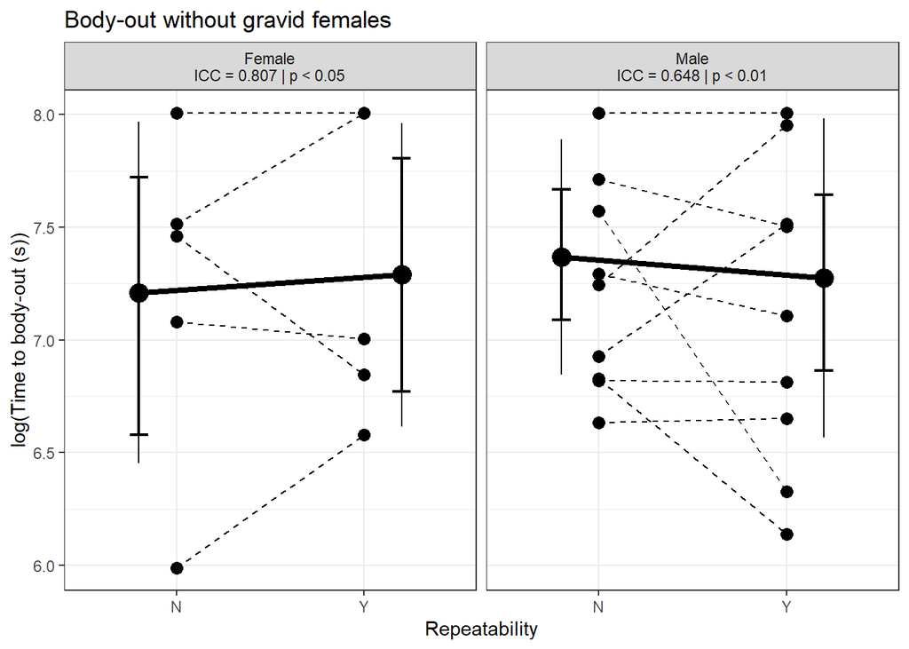

```r
# Plot
ggplot(data = repeat_ind_no_gravid, aes(x = Repeatability, y = log1p(Time_body_out_sec_raw))) +
  theme_bw() +
  facet_wrap(~ Sex, labeller = labeller(Sex =
                                          c("F" = "Female\nICC = 0.807 | p < 0.05",
                                            "M" = "Male\nICC = 0.648 | p < 0.01"))) +
  stat_summary(
    geom = "errorbar",
    fun.data = mean_cl_boot,
    width = 0.1,
    size = 0.8,
    col = "black",
    position = position_nudge(x = c(-0.2, 0.2))) +
  geom_point(size = 3) +
  stat_summary(fun.y = mean, position = position_nudge(x = c(-0.2, 0.2)), size = 1) +
  stat_summary(aes(group = 1), fun.y = mean, geom = "line", size = 1.5, linetype = "solid", position = position_nudge(x = c(-0.2, 0.2))) +
  stat_summary(fun.data = mean_sdl, fun.args = list(mult = 1),
               geom = "pointrange", color = "black", size = 0.2,
               position = position_nudge(x = c(-0.2, 0.2))) +
  geom_line(aes(group = Snake_ID), size = 0.5, linetype = "dashed") +
  ylab("log(Time to body-out (s))") +
  ggtitle("Body-out without gravid females") +
  theme(plot.caption = element_text(hjust = 0.5))
```

```r
# ANOVA differences in mean
# Females
anova_F <- aov(log(Time_body_out_sec_raw) ~ repeat_trial, data = icc_data_F)

summary(anova_F)
```

```
             Df Sum Sq Mean Sq F value Pr(>F)
repeat_trial  1  0.016  0.0155    0.03  0.866
Residuals     8  4.116  0.5145
```

```r
# Males
anova_M <- aov(log(Time_body_out_sec_raw) ~ repeat_trial, data = icc_data_M)

summary(anova_M)
```

```
             Df Sum Sq Mean Sq F value Pr(>F)
repeat_trial  1  0.048  0.0477   0.123  0.729
Residuals    20  7.745  0.3872
```

### 5.1.3 Visual exploration

#### 5.1.3.1 Including gravid females

```r
# Only those ind that got out of the initial refuge on time
summary_tracking_complete_outside <- summary_tracking_complete[summary_tracking_complete$Time_body_out_sec_raw != time_limit, ]

# select repeated individuals within the ones that got out
repeat_ID_outside <- summary_tracking_complete_outside$Snake_ID[duplicated(summary_tracking_complete_outside$Snake_ID)]

# select individuals
repeat_ind_outside <- summary_tracking_complete_outside[summary_tracking_complete_outside$Snake_ID %in% repeat_ID_outside, ]

# assign 1 to first trials
repeat_ind_outside$repeat_trial <- 1

for (i in 1:nrow(repeat_ind_outside)){

  # And if duplicated, assign 2
  if(duplicated(repeat_ind_outside$ID)[i] == T){

    repeat_ind_outside$repeat_trial[i] <- 2

  } else {

  }

}

# Order snakes by ID (first the first trial and second the repeatiblity test)
repeat_ind_outside <- repeat_ind_outside[order(repeat_ind_outside$ID), ]

# We extract the variable that we want to test repeatability
icc_data <- as.data.frame(repeat_ind_outside[, c("Snake_ID", "Visual_exp", "repeat_trial", "Sex")])

# divide by sex
icc_data_F <- icc_data[icc_data$Sex == "F", ]

icc_data_M <- icc_data[icc_data$Sex == "M", ]

# Delete sex column
icc_data_F <- icc_data_F[, -c(4)]

icc_data_M <- icc_data_M[, -c(4)]

# Put it in wide format
icc_data_wide_F <- reshape(icc_data_F, idvar = "Snake_ID", timevar = "repeat_trial", direction = "wide")

icc_data_wide_M <- reshape(icc_data_M, idvar = "Snake_ID", timevar = "repeat_trial", direction = "wide")

# Delete ID column
icc_data_wide_F <- icc_data_wide_F[, -1]

icc_data_wide_M <- icc_data_wide_M[, -1]

# Change column names
colnames(icc_data_wide_F) <- c("First_trial", "Second_trial")

colnames(icc_data_wide_M) <- c("First_trial", "Second_trial")

# log transform varaibles
icc_data_wide_F <- log1p(icc_data_wide_F)

icc_data_wide_M <- log1p(icc_data_wide_M)

# Consistency (ICC)
# Females
irr::icc(icc_data_wide_F, model = "oneway", type = "consistency", unit = "single")
```

```
 Single Score Intraclass Correlation

   Model: oneway
   Type : consistency

   Subjects = 4
     Raters = 2
     ICC(1) = -0.0178

 F-Test, H0: r0 = 0 ; H1: r0 > 0
     F(3,4) = 0.965 , p = 0.491

 95%-Confidence Interval for ICC Population Values:
  -0.824 < ICC < 0.872
```

```r
# Males
irr::icc(icc_data_wide_M, model = "oneway", type = "consistency", unit = "single")
```

```
 Single Score Intraclass Correlation

   Model: oneway
   Type : consistency

   Subjects = 8
     Raters = 2
     ICC(1) = 0.313

 F-Test, H0: r0 = 0 ; H1: r0 > 0
     F(7,8) = 1.91 , p = 0.192

 95%-Confidence Interval for ICC Population Values:
  -0.406 < ICC < 0.807
```

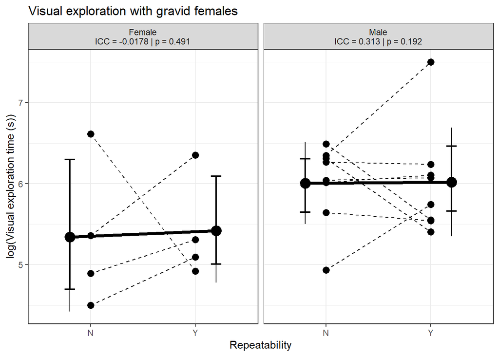

```r
# Plot
ggplot(data = repeat_ind_outside, aes(x = Repeatability, y = log1p(Visual_exp))) +
  theme_bw() +
  facet_wrap(~ Sex, labeller = labeller(Sex =
                                          c("F" = "Female\nICC = -0.0178 | p = 0.491",
                                            "M" = "Male\nICC = 0.313 | p = 0.192"))) +
  stat_summary(
    geom = "errorbar",
    fun.data = mean_cl_boot,
    width = 0.1,
    size = 0.8,
    col = "black",
    position = position_nudge(x = c(-0.2, 0.2))) +
  geom_point(size = 3) +
  stat_summary(fun.y = mean, position = position_nudge(x = c(-0.2, 0.2)), size = 1) +
  stat_summary(aes(group = 1), fun.y = mean, geom = "line", size = 1.5, linetype = "solid", position = position_nudge(x = c(-0.2, 0.2))) +
  stat_summary(fun.data = mean_sdl, fun.args = list(mult = 1),
               geom = "pointrange", color = "black", size = 0.2,
               position = position_nudge(x = c(-0.2, 0.2))) +
  geom_line(aes(group = Snake_ID), size = 0.5, linetype = "dashed") +
  ylab("log(Visual exploration time (s))") +
  ggtitle("Visual exploration with gravid females") +
  theme(plot.caption = element_text(hjust = 0.5))
```

```r
# ANOVA differences in mean
# Females
anova_F <- aov(log1p(Visual_exp) ~ repeat_trial, data = icc_data_F)

summary(anova_F)
```

```
             Df Sum Sq Mean Sq F value Pr(>F)
repeat_trial  1  0.012  0.0123    0.02  0.893
Residuals     6  3.762  0.6270
```

```r
# Males
anova_M <- aov(log1p(Visual_exp) ~ repeat_trial, data = icc_data_M)

summary(anova_M)
```

```
             Df Sum Sq Mean Sq F value Pr(>F)
repeat_trial  1  0.001  0.0008   0.002  0.963
Residuals    14  4.946  0.3533
```

#### 5.1.3.2 Excluding gravid females

```r
# Only those ind that got out of the initial refuge on time
summary_tracking_complete_outside <- summary_tracking_complete[summary_tracking_complete$Time_body_out_sec_raw != time_limit, ]

# select repeated individuals within the ones that got out
repeat_ID_outside <- summary_tracking_complete_outside$Snake_ID[duplicated(summary_tracking_complete_outside$Snake_ID)]

# select individuals
repeat_ind_outside <- summary_tracking_complete_outside[summary_tracking_complete_outside$Snake_ID %in% repeat_ID_outside, ]

# Data frame without gravid females
repeat_ind_outside_no_gravid <- repeat_ind_outside[repeat_ind_outside$N_eggs == 0, ]

# assign 1 to first trials
repeat_ind_outside$repeat_trial <- 1

for (i in 1:nrow(repeat_ind_outside)){

  # And if duplicated, assign 2
  if(duplicated(repeat_ind_outside$ID)[i] == T){

    repeat_ind_outside$repeat_trial[i] <- 2

  } else {

  }

}

# Order snakes by ID (first the first trial and second the repeatiblity test)
repeat_ind_outside <- repeat_ind_outside[order(repeat_ind_outside$ID), ]

# We extract the variable that we want to test repeatability
icc_data <- as.data.frame(repeat_ind_outside[, c("Snake_ID", "Visual_exp", "repeat_trial", "Sex", "N_eggs")])

# Do not include gravid females
icc_data <- icc_data[icc_data$N_eggs == 0, ]

# divide by sex
icc_data_F <- icc_data[icc_data$Sex == "F", ]

icc_data_M <- icc_data[icc_data$Sex == "M", ]

# Delete sex and n_eggs columns
icc_data_F <- icc_data_F[, -c(4, 5)]

icc_data_M <- icc_data_M[, -c(4, 5)]

# Put it in wide format
icc_data_wide_F <- reshape(icc_data_F, idvar = "Snake_ID", timevar = "repeat_trial", direction = "wide")

icc_data_wide_M <- reshape(icc_data_M, idvar = "Snake_ID", timevar = "repeat_trial", direction = "wide")

# Delete ID column
icc_data_wide_F <- icc_data_wide_F[, -1]

icc_data_wide_M <- icc_data_wide_M[, -1]

# Change column names
colnames(icc_data_wide_F) <- c("First_trial", "Second_trial")

colnames(icc_data_wide_M) <- c("First_trial", "Second_trial")

# log transform varaibles
icc_data_wide_F <- log1p(icc_data_wide_F)

icc_data_wide_M <- log1p(icc_data_wide_M)

# Consistency (ICC)
# Females
irr::icc(icc_data_wide_F, model = "oneway", type = "consistency", unit = "single")
```

```
 Single Score Intraclass Correlation

   Model: oneway
   Type : consistency

   Subjects = 3
     Raters = 2
     ICC(1) = 0.402

 F-Test, H0: r0 = 0 ; H1: r0 > 0
     F(2,3) = 2.35 , p = 0.244

 95%-Confidence Interval for ICC Population Values:
  -0.745 < ICC < 0.978
```

```r
# Males
irr::icc(icc_data_wide_M, model = "oneway", type = "consistency", unit = "single")
```

```
 Single Score Intraclass Correlation

   Model: oneway
   Type : consistency

   Subjects = 8
     Raters = 2
     ICC(1) = 0.313

 F-Test, H0: r0 = 0 ; H1: r0 > 0
     F(7,8) = 1.91 , p = 0.192

 95%-Confidence Interval for ICC Population Values:
  -0.406 < ICC < 0.807
```

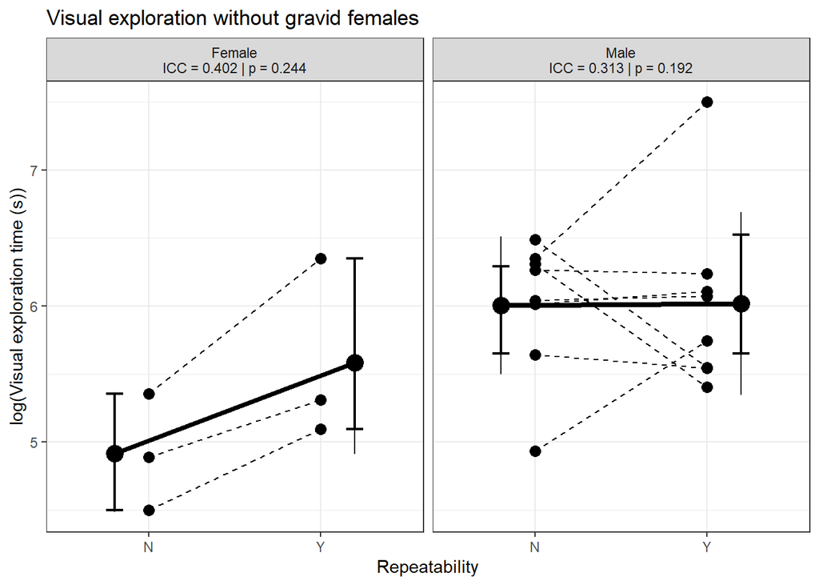

```r
# Plot
ggplot(data = repeat_ind_outside_no_gravid, aes(x = Repeatability, y = log1p(Visual_exp))) +
  theme_bw() +
  facet_wrap(~ Sex, labeller = labeller(Sex =
                                          c("F" = "Female\nICC = 0.402 | p = 0.244",
                                            "M" = "Male\nICC = 0.313 | p = 0.192"))) +
  stat_summary(
    geom = "errorbar",
    fun.data = mean_cl_boot,
    width = 0.1,
    size = 0.8,
    col = "black",
    position = position_nudge(x = c(-0.2, 0.2))) +
  geom_point(size = 3) +
  stat_summary(fun.y = mean, position = position_nudge(x = c(-0.2, 0.2)), size = 1) +
  stat_summary(aes(group = 1), fun.y = mean, geom = "line", size = 1.5, linetype = "solid", position = position_nudge(x = c(-0.2, 0.2))) +
  stat_summary(fun.data = mean_sdl, fun.args = list(mult = 1),
               geom = "pointrange", color = "black", size = 0.2,
               position = position_nudge(x = c(-0.2, 0.2))) +
  geom_line(aes(group = Snake_ID), size = 0.5, linetype = "dashed") +
  ylab("log(Visual exploration time (s))") +
  ggtitle("Visual exploration without gravid females") +
  theme(plot.caption = element_text(hjust = 0.5))
```

```r
# ANOVA differences in mean
# Females
anova_F <- aov(log1p(Visual_exp) ~ repeat_trial, data = icc_data_F)

summary(anova_F)
```

```
             Df Sum Sq Mean Sq F value Pr(>F)
repeat_trial  1 0.6708  0.6708   2.109   0.22
Residuals     4 1.2725  0.3181
```

```r
# Males
anova_M <- aov(log1p(Visual_exp) ~ repeat_trial, data = icc_data_M)

summary(anova_M)
```

```
             Df Sum Sq Mean Sq F value Pr(>F)
repeat_trial  1  0.001  0.0008   0.002  0.963
Residuals    14  4.946  0.3533
```

## 5.2 2023 + 2024 snakes

In this section, for the moment we can only see if there are differences between CORE or FRONT, as at the moment we do not have the sex of the individuals or their pregnancy status.

```r
# detect duplicated ID from 2023 data
repeat_ID <- summary_tracking_complete$Snake_ID[duplicated(summary_tracking_complete$Snake_ID)]

# Select ind with more than one tracking
repeat_ind <- summary_tracking_complete[summary_tracking_complete$Snake_ID %in% repeat_ID, ]

# assign 1 to first trials
repeat_ind$repeat_trial <- 1

for (i in 1:nrow(repeat_ind)){

  # And if duplicated, assign 2
  if(duplicated(repeat_ind$ID)[i] == T){

    repeat_ind$repeat_trial[i] <- 2

  } else {

  }

}

# Order snakes by ID (first the first trial and second the repeatiblity test)
repeat_ind <- repeat_ind[order(repeat_ind$ID), ]

# Reduced data frame
repeat_ind_2024_merged <- repeat_ind[, c("Snake_ID", "Inv_situation", "Capture_day", "Time_head_out_sec_raw", "Time_body_out_sec_raw", "Repeatability", "Tracking", "Year_invasion", "Distance_Noahs", "SVL", "Real_Weight", "Condition", "Sex", "N_eggs", "repeat_trial")]

# 2024 data
repeat_2024 <- Snake_data[year(Snake_data$Capture_day) == 2024, ]

# assign 1 to first trials
repeat_2024$repeat_trial <- 1

for (i in 1:nrow(repeat_2024)){

  # And if duplicated, assign 2
  if(duplicated(repeat_2024$Snake_ID)[i] == T){

    repeat_2024$repeat_trial[i] <- 2

  } else {

  }

}

# Reduced data frame
repeat_2024_merged_2 <- repeat_2024[, c("Snake_ID", "Inv_situation", "Capture_day", "Time_head_out_sec_raw", "Time_body_out_sec_raw", "Repeatability", "Tracking", "Year_invasion", "Distance_Noahs", "repeat_trial")]

# Date format
repeat_ind_2024_merged$Capture_day <- as_datetime(repeat_ind_2024_merged$Capture_day)

repeat_ind_2024_merged$Capture_day <- as_datetime(repeat_ind_2024_merged$Capture_day)

# Tiem to head-out / body-out as numeric
repeat_2024_merged_2$Time_head_out_sec_raw <- as.numeric(repeat_2024_merged_2$Time_head_out_sec_raw)

repeat_2024_merged_2$Time_body_out_sec_raw <- as.numeric(repeat_2024_merged_2$Time_body_out_sec_raw)

# If snake didn't get out, the number of seconds is 3000
repeat_2024_merged_2 <- repeat_2024_merged_2 %>% mutate(Time_head_out_sec_raw = ifelse(is.na(Time_head_out_sec_raw), time_limit, Time_head_out_sec_raw))

repeat_2024_merged_2 <- repeat_2024_merged_2 %>% mutate(Time_body_out_sec_raw = ifelse(is.na(Time_body_out_sec_raw), time_limit, Time_body_out_sec_raw))

# Merge data frames
merged_repeat_2024 <- bind_rows(repeat_ind_2024_merged, repeat_2024_merged_2)

merged_repeat_2024 <- merged_repeat_2024[order(merged_repeat_2024$Snake_ID), ]

# Check that all data over 3000s is correctly censored
for(i in 1:nrow(merged_repeat_2024)){

  if(merged_repeat_2024$Time_head_out_sec_raw[i] > time_limit){

    merged_repeat_2024$Time_head_out_sec_raw[i] <- time_limit

    merged_repeat_2024$Time_body_out_sec_raw[i] <- time_limit

  } else { }

}
```

### 5.2.1 Head-out

```r
# General ICC
# We extract the variable that we want to test repeatability
icc_data <- as.data.frame(merged_repeat_2024[, c("Snake_ID", "Time_head_out_sec_raw", "repeat_trial")])

# Put it in wide format
icc_data_wide <- reshape(icc_data, idvar = "Snake_ID", timevar = "repeat_trial", direction = "wide")

# Delete ID column
icc_data_wide <- icc_data_wide[, -1]

# Change column names
colnames(icc_data_wide) <- c("First_trial", "Second_trial")

# log transform varaibles
icc_data_wide <- log1p(icc_data_wide)

# Consistency (ICC)
irr::icc(icc_data_wide, model = "oneway", type = "consistency", unit = "single")
```

```
 Single Score Intraclass Correlation

   Model: oneway
   Type : consistency

   Subjects = 34
     Raters = 2
     ICC(1) = 0.534

 F-Test, H0: r0 = 0 ; H1: r0 > 0
   F(33,34) = 3.29 , p = 0.000418

 95%-Confidence Interval for ICC Population Values:
  0.247 < ICC < 0.736
```

```r
# Divide into CORE and FRONT
merged_repeat_2024_core <- merged_repeat_2024[merged_repeat_2024$Inv_situation == "CORE", ]

merged_repeat_2024_front <- merged_repeat_2024[merged_repeat_2024$Inv_situation == "FRONT", ]

# CORE
# We extract the variable that we want to test repeatability
icc_data <- as.data.frame(merged_repeat_2024_core[, c("Snake_ID", "Time_head_out_sec_raw", "repeat_trial")])

# Put it in wide format
icc_data_wide <- reshape(icc_data, idvar = "Snake_ID", timevar = "repeat_trial", direction = "wide")

# Delete ID column
icc_data_wide <- icc_data_wide[, -1]

# Change column names
colnames(icc_data_wide) <- c("First_trial", "Second_trial")

# log transform varaibles
icc_data_wide <- log1p(icc_data_wide)

# Consistency (ICC)
irr::icc(icc_data_wide, model = "oneway", type = "consistency", unit = "single")
```

```
 Single Score Intraclass Correlation

   Model: oneway
   Type : consistency

   Subjects = 17
     Raters = 2
     ICC(1) = 0.368

 F-Test, H0: r0 = 0 ; H1: r0 > 0
   F(16,17) = 2.16 , p = 0.0623

 95%-Confidence Interval for ICC Population Values:
  -0.11 < ICC < 0.711
```

```r
# FRONT
# We extract the variable that we want to test repeatability
icc_data <- as.data.frame(merged_repeat_2024_front[, c("Snake_ID", "Time_head_out_sec_raw", "repeat_trial")])

# Put it in wide format
icc_data_wide <- reshape(icc_data, idvar = "Snake_ID", timevar = "repeat_trial", direction = "wide")

# Delete ID column
icc_data_wide <- icc_data_wide[, -1]

# Change column names
colnames(icc_data_wide) <- c("First_trial", "Second_trial")

# log transform varaibles
icc_data_wide <- log1p(icc_data_wide)

# Consistency (ICC)
irr::icc(icc_data_wide, model = "oneway", type = "consistency", unit = "single")
```

```
 Single Score Intraclass Correlation

   Model: oneway
   Type : consistency

   Subjects = 17
     Raters = 2
     ICC(1) = 0.678

 F-Test, H0: r0 = 0 ; H1: r0 > 0
   F(16,17) = 5.22 , p = 0.000762

 95%-Confidence Interval for ICC Population Values:
  0.318 < ICC < 0.869
```

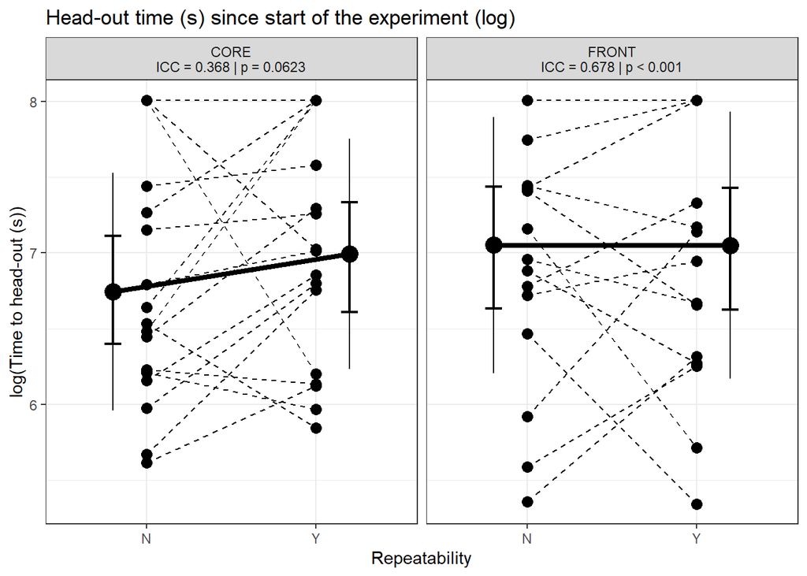

```r
# Plot
ggplot(data = merged_repeat_2024, aes(x = Repeatability, y = log1p(Time_head_out_sec_raw))) +
  theme_bw() +
  facet_wrap(~ Inv_situation, labeller = labeller(Inv_situation =
                                          c("CORE" = "CORE\nICC = 0.368 | p = 0.0623",
                                            "FRONT" = "FRONT\nICC = 0.678 | p < 0.001"))) +
  stat_summary(
    geom = "errorbar",
    fun.data = mean_cl_boot,
    width = 0.1,
    size = 0.8,
    col = "black",
    position = position_nudge(x = c(-0.2, 0.2))) +
  geom_point(size = 3) +
  stat_summary(fun.y = mean, position = position_nudge(x = c(-0.2, 0.2)), size = 1) +
  stat_summary(aes(group = 1), fun.y = mean, geom = "line", size = 1.5, linetype = "solid", position = position_nudge(x = c(-0.2, 0.2))) +
  stat_summary(fun.data = mean_sdl, fun.args = list(mult = 1),
               geom = "pointrange", color = "black", size = 0.2,
               position = position_nudge(x = c(-0.2, 0.2))) +
  geom_line(aes(group = Snake_ID), size = 0.5, linetype = "dashed") +
  ylab("log(Time to head-out (s))") +
  ggtitle("Head-out time (s) since start of the experiment (log)") +
  theme(plot.caption = element_text(hjust = 0.5))
```

```r
# ANOVA differences in mean
# CORE
anova_core <- aov(log(Time_head_out_sec_raw) ~ Repeatability, data = merged_repeat_2024_core)

summary(anova_core)
```

```
              Df Sum Sq Mean Sq F value Pr(>F)
Repeatability  1  0.531  0.5311    0.89  0.353
Residuals     32 19.099  0.5968
```

```r
# FRONT
anova_front <- aov(log(Time_head_out_sec_raw) ~ Repeatability, data = merged_repeat_2024_front)

summary(anova_front)
```

```
              Df Sum Sq Mean Sq F value Pr(>F)
Repeatability  1   0.00  0.0000       0  0.995
Residuals     32  23.88  0.7464
```

### 5.2.2 Body-out

```r
# General ICC
# We extract the variable that we want to test repeatability
icc_data <- as.data.frame(merged_repeat_2024[, c("Snake_ID", "Time_body_out_sec_raw", "repeat_trial")])

# Put it in wide format
icc_data_wide <- reshape(icc_data, idvar = "Snake_ID", timevar = "repeat_trial", direction = "wide")

# Delete ID column
icc_data_wide <- icc_data_wide[, -1]

# Change column names
colnames(icc_data_wide) <- c("First_trial", "Second_trial")

# log transform varaibles
icc_data_wide <- log1p(icc_data_wide)

# Consistency (ICC)
irr::icc(icc_data_wide, model = "oneway", type = "consistency", unit = "single")
```

```
 Single Score Intraclass Correlation

   Model: oneway
   Type : consistency

   Subjects = 34
     Raters = 2
     ICC(1) = 0.515

 F-Test, H0: r0 = 0 ; H1: r0 > 0
   F(33,34) = 3.12 , p = 0.000688

 95%-Confidence Interval for ICC Population Values:
  0.222 < ICC < 0.723
```

```r
# Divide into CORE and FRONT
merged_repeat_2024_core <- merged_repeat_2024[merged_repeat_2024$Inv_situation == "CORE", ]

merged_repeat_2024_front <- merged_repeat_2024[merged_repeat_2024$Inv_situation == "FRONT", ]

# CORE
# We extract the variable that we want to test repeatability
icc_data <- as.data.frame(merged_repeat_2024_core[, c("Snake_ID", "Time_body_out_sec_raw", "repeat_trial")])

# Put it in wide format
icc_data_wide <- reshape(icc_data, idvar = "Snake_ID", timevar = "repeat_trial", direction = "wide")

# Delete ID column
icc_data_wide <- icc_data_wide[, -1]

# Change column names
colnames(icc_data_wide) <- c("First_trial", "Second_trial")

# log transform varaibles
icc_data_wide <- log1p(icc_data_wide)

# Consistency (ICC)
irr::icc(icc_data_wide, model = "oneway", type = "consistency", unit = "single")
```

```
 Single Score Intraclass Correlation

   Model: oneway
   Type : consistency

   Subjects = 17
     Raters = 2
     ICC(1) = 0.342

 F-Test, H0: r0 = 0 ; H1: r0 > 0
   F(16,17) = 2.04 , p = 0.0777

 95%-Confidence Interval for ICC Population Values:
  -0.139 < ICC < 0.696
```

```r
# FRONT
# We extract the variable that we want to test repeatability
icc_data <- as.data.frame(merged_repeat_2024_front[, c("Snake_ID", "Time_body_out_sec_raw", "repeat_trial")])

# Put it in wide format
icc_data_wide <- reshape(icc_data, idvar = "Snake_ID", timevar = "repeat_trial", direction = "wide")

# Delete ID column
icc_data_wide <- icc_data_wide[, -1]

# Change column names
colnames(icc_data_wide) <- c("First_trial", "Second_trial")

# log transform varaibles
icc_data_wide <- log1p(icc_data_wide)

# Consistency (ICC)
irr::icc(icc_data_wide, model = "oneway", type = "consistency", unit = "single")
```

```
 Single Score Intraclass Correlation

   Model: oneway
   Type : consistency

   Subjects = 17
     Raters = 2
     ICC(1) = 0.694

 F-Test, H0: r0 = 0 ; H1: r0 > 0
   F(16,17) = 5.53 , p = 0.000533

 95%-Confidence Interval for ICC Population Values:
  0.345 < ICC < 0.876
```

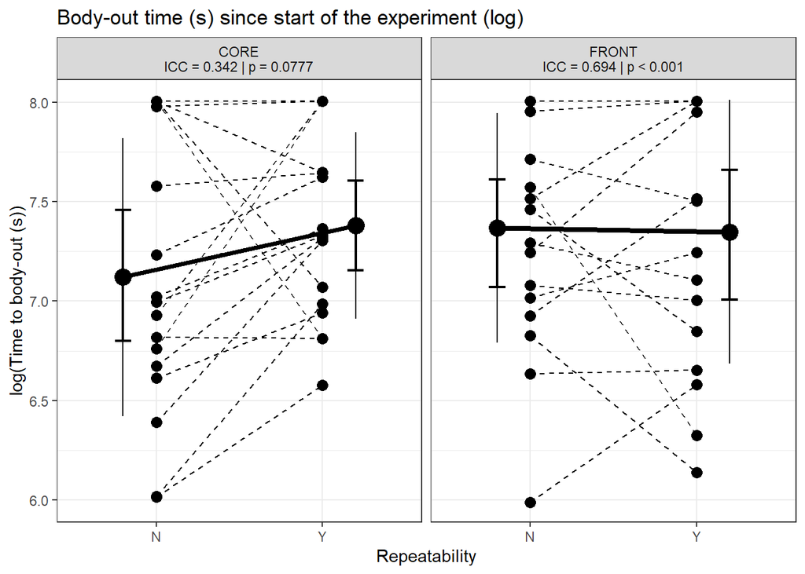

```r
# Plot
ggplot(data = merged_repeat_2024, aes(x = Repeatability, y = log1p(Time_body_out_sec_raw))) +
  theme_bw() +
  facet_wrap(~ Inv_situation, labeller = labeller(Inv_situation =
                                          c("CORE" = "CORE\nICC = 0.342 | p = 0.0777",
                                            "FRONT" = "FRONT\nICC = 0.694 | p < 0.001"))) +
  stat_summary(
    geom = "errorbar",
    fun.data = mean_cl_boot,
    width = 0.1,
    size = 0.8,
    col = "black",
    position = position_nudge(x = c(-0.2, 0.2))) +
  geom_point(size = 3) +
  stat_summary(fun.y = mean, position = position_nudge(x = c(-0.2, 0.2)), size = 1) +
  stat_summary(aes(group = 1), fun.y = mean, geom = "line", size = 1.5, linetype = "solid", position = position_nudge(x = c(-0.2, 0.2))) +
  stat_summary(fun.data = mean_sdl, fun.args = list(mult = 1),
               geom = "pointrange", color = "black", size = 0.2,
               position = position_nudge(x = c(-0.2, 0.2))) +
  geom_line(aes(group = Snake_ID), size = 0.5, linetype = "dashed") +
  ylab("log(Time to body-out (s))") +
  ggtitle("Body-out time (s) since start of the experiment (log)") +
  theme(plot.caption = element_text(hjust = 0.5))
```

```r
# ANOVA differences in mean
# CORE
anova_core <- aov(log(Time_body_out_sec_raw) ~ Repeatability, data = merged_repeat_2024_core)

summary(anova_core)
```

```
              Df Sum Sq Mean Sq F value Pr(>F)
Repeatability  1  0.571  0.5714   1.613  0.213
Residuals     32 11.337  0.3543
```

```r
# FRONT
anova_front <- aov(log(Time_body_out_sec_raw) ~ Repeatability, data = merged_repeat_2024_front)

summary(anova_front)
```

```
              Df Sum Sq Mean Sq F value Pr(>F)
Repeatability  1  0.003  0.0035   0.009  0.925
Residuals     32 12.384  0.3870
```

### 5.2.3 Visual exploration

```r
# Delete rows (individuals) that didn't do body-out under 3000 sec (only for visual exploration)
merged_repeat_2024_outside <- subset(merged_repeat_2024, merged_repeat_2024[["Time_body_out_sec_raw"]] != time_limit)

# Detect those individuals that in both their trials, exited the initial refuge
duplicated_outside <- duplicated(merged_repeat_2024_outside[["Snake_ID"]]) | duplicated(merged_repeat_2024_outside[["Snake_ID"]], fromLast = TRUE)

# Select only those individuals
merged_repeat_2024_outside <- merged_repeat_2024_outside[duplicated_outside, ]

# New variable: exploration time
merged_repeat_2024_outside$Visual_exp <- merged_repeat_2024_outside$Time_body_out_sec_raw - merged_repeat_2024_outside$Time_head_out_sec_raw

# General ICC
# We extract the variable that we want to test repeatability
icc_data <- as.data.frame(merged_repeat_2024_outside[, c("Snake_ID", "Visual_exp", "repeat_trial")])

# Put it in wide format
icc_data_wide <- reshape(icc_data, idvar = "Snake_ID", timevar = "repeat_trial", direction = "wide")

# Delete ID column
icc_data_wide <- icc_data_wide[, -1]

# Change column names
colnames(icc_data_wide) <- c("First_trial", "Second_trial")

# log transform varaibles
icc_data_wide <- log1p(icc_data_wide)

# Consistency (ICC)
irr::icc(icc_data_wide, model = "oneway", type = "consistency", unit = "single")
```

```
 Single Score Intraclass Correlation

   Model: oneway
   Type : consistency

   Subjects = 21
     Raters = 2
     ICC(1) = 0.313

 F-Test, H0: r0 = 0 ; H1: r0 > 0
   F(20,21) = 1.91 , p = 0.0748

 95%-Confidence Interval for ICC Population Values:
  -0.119 < ICC < 0.648
```

```r
# Divide into CORE and FRONT
merged_repeat_2024_core <- merged_repeat_2024_outside[merged_repeat_2024_outside$Inv_situation == "CORE", ]

merged_repeat_2024_front <- merged_repeat_2024_outside[merged_repeat_2024_outside$Inv_situation == "FRONT", ]

# CORE
# We extract the variable that we want to test repeatability
icc_data <- as.data.frame(merged_repeat_2024_core[, c("Snake_ID", "Visual_exp", "repeat_trial")])

# Put it in wide format
icc_data_wide <- reshape(icc_data, idvar = "Snake_ID", timevar = "repeat_trial", direction = "wide")

# Delete ID column
icc_data_wide <- icc_data_wide[, -1]

# Change column names
colnames(icc_data_wide) <- c("First_trial", "Second_trial")

# log transform varaibles
icc_data_wide <- log1p(icc_data_wide)

# Consistency (ICC)
irr::icc(icc_data_wide, model = "oneway", type = "consistency", unit = "single")
```

```
 Single Score Intraclass Correlation

   Model: oneway
   Type : consistency

   Subjects = 10
     Raters = 2
     ICC(1) = 0.369

 F-Test, H0: r0 = 0 ; H1: r0 > 0
    F(9,10) = 2.17 , p = 0.122

 95%-Confidence Interval for ICC Population Values:
  -0.271 < ICC < 0.792
```

```r
# FRONT
# We extract the variable that we want to test repeatability
icc_data <- as.data.frame(merged_repeat_2024_front[, c("Snake_ID", "Visual_exp", "repeat_trial")])

# Put it in wide format
icc_data_wide <- reshape(icc_data, idvar = "Snake_ID", timevar = "repeat_trial", direction = "wide")

# Delete ID column
icc_data_wide <- icc_data_wide[, -1]

# Change column names
colnames(icc_data_wide) <- c("First_trial", "Second_trial")

# log transform varaibles
icc_data_wide <- log1p(icc_data_wide)

# Consistency (ICC)
irr::icc(icc_data_wide, model = "oneway", type = "consistency", unit = "single")
```

```
 Single Score Intraclass Correlation

   Model: oneway
   Type : consistency

   Subjects = 11
     Raters = 2
     ICC(1) = 0.291

 F-Test, H0: r0 = 0 ; H1: r0 > 0
   F(10,11) = 1.82 , p = 0.17

 95%-Confidence Interval for ICC Population Values:
  -0.319 < ICC < 0.739
```

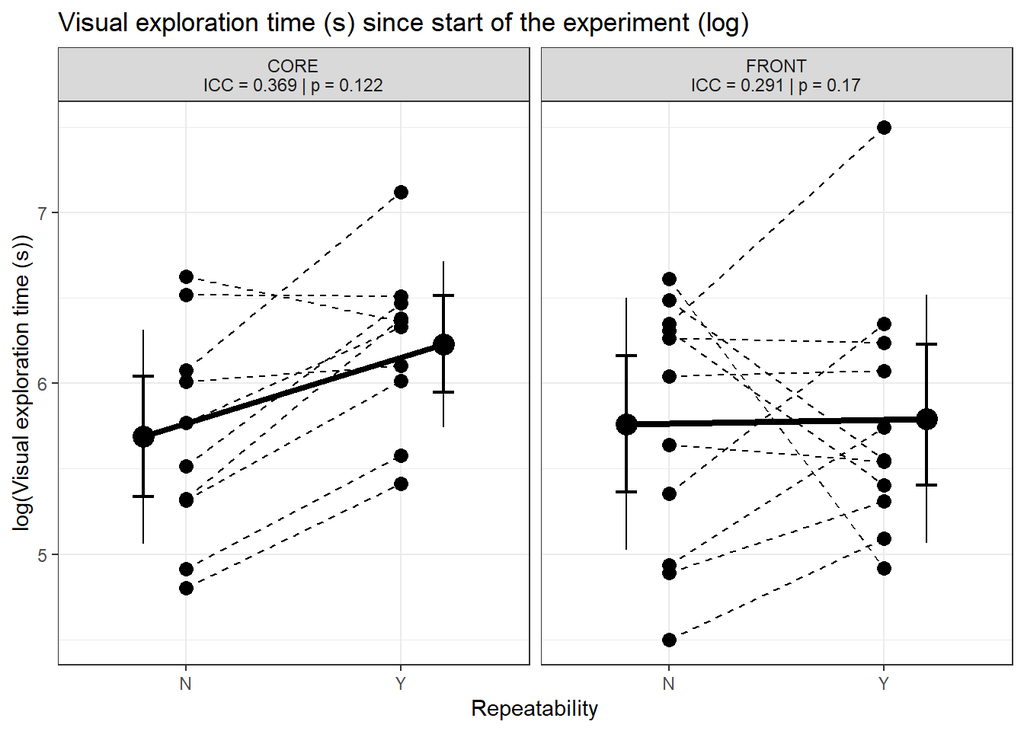

```r
# Plot
ggplot(data = merged_repeat_2024_outside, aes(x = Repeatability, y = log1p(Visual_exp))) +
  theme_bw() +
  facet_wrap(~ Inv_situation, labeller = labeller(Inv_situation =
                                          c("CORE" = "CORE\nICC = 0.369 | p = 0.122",
                                            "FRONT" = "FRONT\nICC = 0.291 | p = 0.17"))) +
  stat_summary(
    geom = "errorbar",
    fun.data = mean_cl_boot,
    width = 0.1,
    size = 0.8,
    col = "black",
    position = position_nudge(x = c(-0.2, 0.2))) +
  geom_point(size = 3) +
  stat_summary(fun.y = mean, position = position_nudge(x = c(-0.2, 0.2)), size = 1) +
  stat_summary(aes(group = 1), fun.y = mean, geom = "line", size = 1.5, linetype = "solid", position = position_nudge(x = c(-0.2, 0.2))) +
  stat_summary(fun.data = mean_sdl, fun.args = list(mult = 1),
               geom = "pointrange", color = "black", size = 0.2,
               position = position_nudge(x = c(-0.2, 0.2))) +
  geom_line(aes(group = Snake_ID), size = 0.5, linetype = "dashed") +
  ylab("log(Visual exploration time (s))") +
  ggtitle("Visual exploration time (s) since start of the experiment (log)") +
  theme(plot.caption = element_text(hjust = 0.5))
```

```r
# ANOVA differences in mean
# CORE
anova_core <- aov(log(Visual_exp) ~ Repeatability, data = merged_repeat_2024_core)

summary(anova_core)
```

```
              Df Sum Sq Mean Sq F value Pr(>F)
Repeatability  1  1.475  1.4746    4.67 0.0444 *
Residuals     18  5.684  0.3158
---
Signif. codes:  0 '***' 0.001 '**' 0.01 '*' 0.05 '.' 0.1 ' ' 1
```

```r
# FRONT
anova_front <- aov(log(Visual_exp) ~ Repeatability, data = merged_repeat_2024_front)

summary(anova_front)
```

```
              Df Sum Sq Mean Sq F value Pr(>F)
Repeatability  1  0.005  0.0052    0.01  0.923
Residuals     20 10.778  0.5389
```

# 6 Survival analysis + Cox regression

Here we performed a survival analysis and a Cox regression to see if there are differences between snakes from the invasion front (*FRONT*) and those from the initially invaded zone (*CORE*) for the time it takes for the snakes to get their heads out of the initial refuge for the first time (*Head-out*) and to get completely out of the initial refuge for the first time (*Body-out*). This analysis doesn’t include 2024 snakes.

## 6.1 No log-transformation

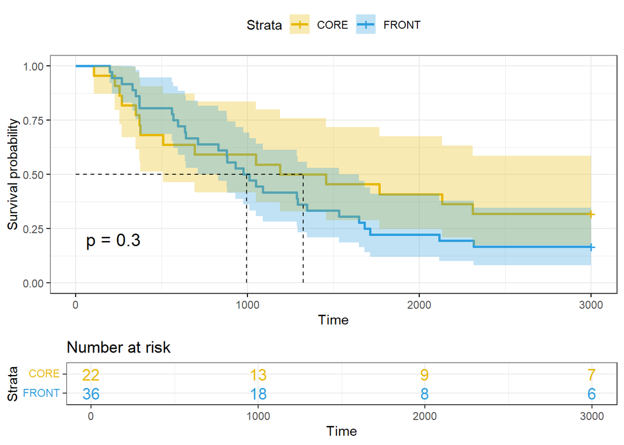

```r
# We add columns for saying if data is censored (0) or the event has happened within the time frame (1)
summary_tracking_complete_no_rep <- add_column(summary_tracking_complete_no_rep, Head_out_01 = NA, .after = "Time_head_out_sec_raw")

summary_tracking_complete_no_rep <- add_column(summary_tracking_complete_no_rep, Body_out_01 = NA, .after = "Time_body_out_sec_raw")

# 1 for event (head-out/body-out) and 0 for censored data
for(i in 1:nrow(summary_tracking_complete_no_rep)){

  if(summary_tracking_complete_no_rep$Time_head_out_sec_raw[i] == 3000){

    summary_tracking_complete_no_rep$Head_out_01[i] <- 0

  } else {

    summary_tracking_complete_no_rep$Head_out_01[i] <- 1

  }

  if(summary_tracking_complete_no_rep$Time_body_out_sec_raw[i] == 3000){

    summary_tracking_complete_no_rep$Body_out_01[i] <- 0

  } else {

    summary_tracking_complete_no_rep$Body_out_01[i] <- 1

  }

}

# Head-out
fit_head_out <- survfit(Surv(Time_head_out_sec_raw, Head_out_01) ~ Inv_situation, data = summary_tracking_complete_no_rep)

ggsurvplot(fit_head_out,
           pval = TRUE,
           conf.int = TRUE,
           risk.table = TRUE,
           risk.table.col = "strata",
           linetype = c(1, 1),
           ggtheme = theme_bw(),
           palette = c("#E7B800", "#2E9FDF"),
           surv.median.line = "hv",
           legend.labs = c("CORE", "FRONT"))
```

```r
coxph(Surv(Time_head_out_sec_raw, Head_out_01) ~ Inv_situation, data = summary_tracking_complete_no_rep)
```

```
Call:
coxph(formula = Surv(Time_head_out_sec_raw, Head_out_01) ~ Inv_situation,
    data = summary_tracking_complete_no_rep)

                     coef exp(coef) se(coef)     z     p
Inv_situationFRONT 0.3264    1.3860   0.3189 1.024 0.306

Likelihood ratio test=1.08  on 1 df, p=0.2984
n= 58, number of events= 45
```

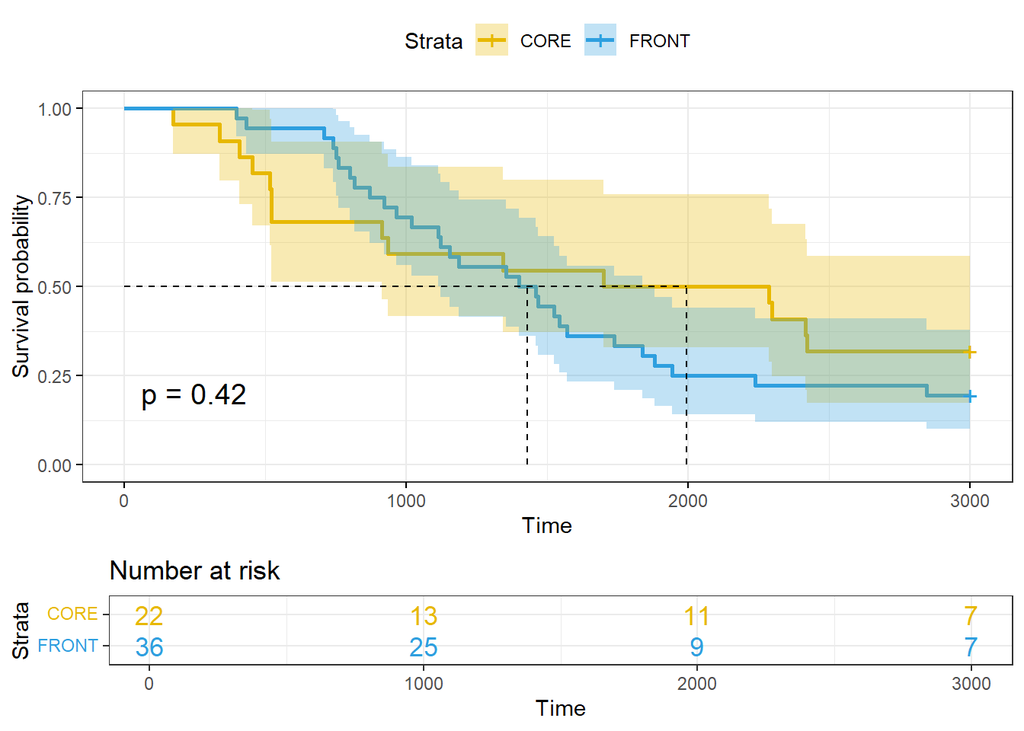

```r
# Body-out
fit_body_out <- survfit(Surv(Time_body_out_sec_raw, Body_out_01) ~ Inv_situation, data = summary_tracking_complete_no_rep)

ggsurvplot(fit_body_out,
           pval = TRUE,
           conf.int = TRUE,
           risk.table = TRUE,
           risk.table.col = "strata",
           linetype = c(1, 1),
           ggtheme = theme_bw(),
           palette = c("#E7B800", "#2E9FDF"),
           surv.median.line = "hv",
           legend.labs = c("CORE", "FRONT"))
```

```r
coxph(Surv(Time_body_out_sec_raw, Body_out_01) ~ Inv_situation, data = summary_tracking_complete_no_rep)
```

```
Call:
coxph(formula = Surv(Time_body_out_sec_raw, Body_out_01) ~ Inv_situation,
    data = summary_tracking_complete_no_rep)

                     coef exp(coef) se(coef)     z     p
Inv_situationFRONT 0.2578    1.2940   0.3216 0.802 0.423

Likelihood ratio test=0.66  on 1 df, p=0.4172
n= 58, number of events= 44
```

## 6.2 Log-transformation

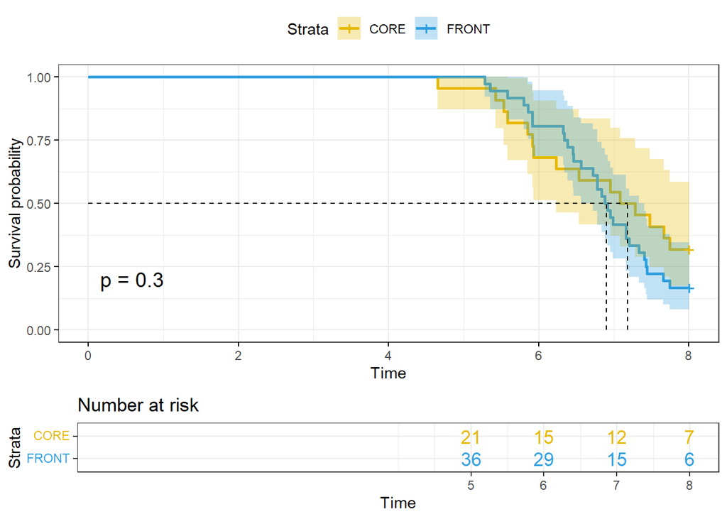

```r
# Head-out
fit_head_out <- survfit(Surv(log(Time_head_out_sec_raw), Head_out_01) ~ Inv_situation, data = summary_tracking_complete_no_rep)

ggsurvplot(fit_head_out,
           pval = TRUE,
           conf.int = TRUE,
           risk.table = TRUE,
           risk.table.col = "strata",
           linetype = c(1, 1),
           ggtheme = theme_bw(),
           palette = c("#E7B800", "#2E9FDF"),
           surv.median.line = "hv",
           legend.labs = c("CORE", "FRONT"))
```

```r
coxph(Surv(log(Time_head_out_sec_raw), Head_out_01) ~ Inv_situation, data = summary_tracking_complete_no_rep)
```

```
Call:
coxph(formula = Surv(log(Time_head_out_sec_raw), Head_out_01) ~
    Inv_situation, data = summary_tracking_complete_no_rep)

                     coef exp(coef) se(coef)     z     p
Inv_situationFRONT 0.3264    1.3860   0.3189 1.024 0.306

Likelihood ratio test=1.08  on 1 df, p=0.2984
n= 58, number of events= 45
```

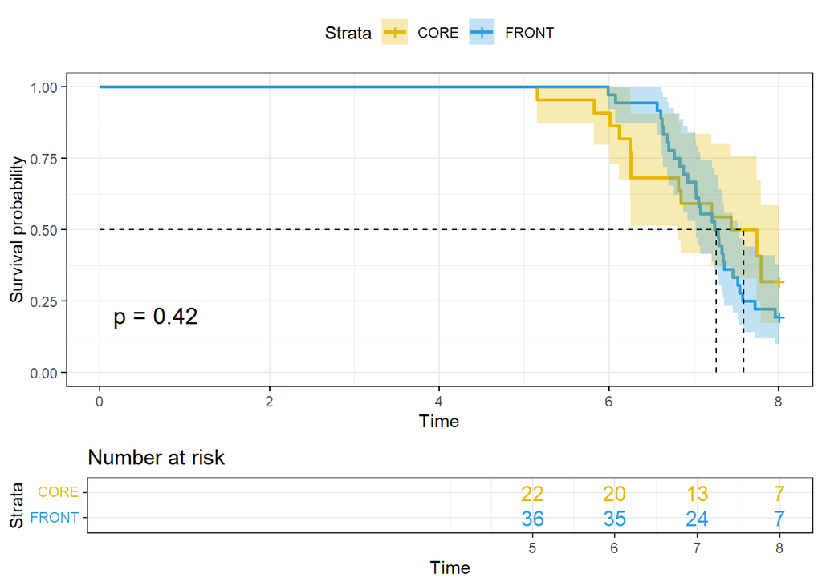

```r
# Body-out
fit_body_out <- survfit(Surv(log(Time_body_out_sec_raw), Body_out_01) ~ Inv_situation, data = summary_tracking_complete_no_rep)

ggsurvplot(fit_body_out,
           pval = TRUE,
           conf.int = TRUE,
           risk.table = TRUE,
           risk.table.col = "strata",
           linetype = c(1, 1),
           ggtheme = theme_bw(),
           palette = c("#E7B800", "#2E9FDF"),
           surv.median.line = "hv",
           legend.labs = c("CORE", "FRONT"))
```

```r
coxph(Surv(log(Time_body_out_sec_raw), Body_out_01) ~ Inv_situation, data = summary_tracking_complete_no_rep)
```

```
Call:
coxph(formula = Surv(log(Time_body_out_sec_raw), Body_out_01) ~
    Inv_situation, data = summary_tracking_complete_no_rep)

                     coef exp(coef) se(coef)     z     p
Inv_situationFRONT 0.2578    1.2940   0.3216 0.802 0.423

Likelihood ratio test=0.66  on 1 df, p=0.4172
n= 58, number of events= 44
```

# 7 Censored data regressions

In this section, we will use a method for estimating linear regressions with censored data. For the moment, I am including gravid females, but they can be removed.

This part of the analysis has been done with all sexes at the same time, to determine the power of the analyses with censored data, and to see if the results of a normal analysis, one with censored data, and one without censored data are very different from each other. Ideally, it should be separated by gender, for example.

## 7.1 Head-out

### 7.1.1 No log-transformation

```r
# We create a data frame for only the "OLS detect" linear regression
summary_tracking_complete_no_rep_detect <- summary_tracking_complete_no_rep[
  summary_tracking_complete_no_rep$Time_head_out_sec_raw >= 0 &
  summary_tracking_complete_no_rep$Time_head_out_sec_raw < 3000,
]

# ~ Invasion year
# Censored regression
fit.cen <- censReg((Time_head_out_sec_raw) ~ Year_invasion, data = summary_tracking_complete_no_rep, left = -Inf, right = (3000))

summary(fit.cen)
```

```
Call:
censReg(formula = (Time_head_out_sec_raw) ~ Year_invasion, left = -Inf,
    right = (3000), data = summary_tracking_complete_no_rep)

Observations:
         Total  Left-censored     Uncensored Right-censored
            58              0             45             13

Coefficients:
                Estimate Std. error t value Pr(> t)
(Intercept)    8.818e+04  1.558e+05   0.566   0.571
Year_invasion -4.290e+01  7.713e+01  -0.556   0.578
logSigma       7.151e+00  1.132e-01  63.168  <2e-16 ***
---
Signif. codes:  0 '***' 0.001 '**' 0.01 '*' 0.05 '.' 0.1 ' ' 1

Newton-Raphson maximisation, 8 iterations
Return code 8: successive function values within relative tolerance limit (reltol)
Log-likelihood: -400.2705 on 3 Df
```

```r
# Fit a line using OLS regression (linear regression)
fit.OLS <- lm((Time_head_out_sec_raw) ~ Year_invasion, data = summary_tracking_complete_no_rep)

summary(fit.OLS)
```

```
Call:
lm(formula = (Time_head_out_sec_raw) ~ Year_invasion, data = summary_tracking_complete_no_rep)

Residuals:
    Min      1Q  Median      3Q     Max
-1369.4  -932.2  -284.5   818.1  1794.6

Coefficients:
               Estimate Std. Error t value Pr(>|t|)
(Intercept)    88169.46  121776.85   0.724    0.472
Year_invasion    -42.97      60.30  -0.713    0.479

Residual standard error: 1035 on 56 degrees of freedom
Multiple R-squared:  0.008987,  Adjusted R-squared:  -0.008709
F-statistic: 0.5079 on 1 and 56 DF,  p-value: 0.479
```

```r
# fit regression only of non-censored data
fit.detect <- lm(Time_head_out_sec_raw ~ Year_invasion, data = summary_tracking_complete_no_rep_detect)

summary(fit.detect)
```

```
Call:
lm(formula = Time_head_out_sec_raw ~ Year_invasion, data = summary_tracking_complete_no_rep_detect)

Residuals:
   Min     1Q Median     3Q    Max
-850.0 -538.7 -121.0  313.2 1449.6

Coefficients:
               Estimate Std. Error t value Pr(>|t|)
(Intercept)   -44861.35   90529.86  -0.496    0.623
Year_invasion     22.67      44.82   0.506    0.616

Residual standard error: 626.3 on 43 degrees of freedom
Multiple R-squared:  0.005912,  Adjusted R-squared:  -0.01721
F-statistic: 0.2557 on 1 and 43 DF,  p-value: 0.6156
```

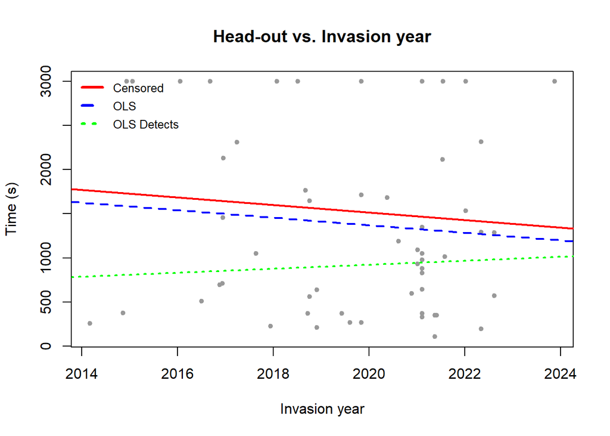

```r
# Plot the results
lineplot <- function() {

  # Add lines
  abline(coef(fit.cen)[1:2], col = "red", lwd = 2)
  abline(coef(fit.OLS), col = "blue", lty = 2, lwd = 2)
  abline(coef(fit.detect), col = "green", lty = 3, lwd = 2)

  # Add legend
  legend(
    "topleft",
    legend = c(
      "Censored",
      "OLS",
      "OLS Detects"
    ),
    lwd = 3 * par("cex"),
    col = c("red", "blue", "green"),
    lty = c(1, 2, 3),
    text.font = 1, bty = "n",
    pt.cex = 1, cex = 0.8, y.intersp = 1.3
  )
}

plot(summary_tracking_complete_no_rep$Year_invasion, (summary_tracking_complete_no_rep$Time_head_out_sec_raw), pch = 19, cex = 0.7, col = 'grey60', main = 'Head-out vs. Invasion year', xlab = "Invasion year", ylab = "Time (s)")

lineplot()
```

```r
# ~ Distance to Noah's garden
# Censored regression
fit.cen <- censReg((Time_head_out_sec_raw) ~ Distance_Noahs, data = summary_tracking_complete_no_rep, left = -Inf, right = (3000))

summary(fit.cen)
```

```
Call:
censReg(formula = (Time_head_out_sec_raw) ~ Distance_Noahs, left = -Inf,
    right = (3000), data = summary_tracking_complete_no_rep)

Observations:
         Total  Left-censored     Uncensored Right-censored
            58              0             45             13

Coefficients:
                Estimate Std. error t value Pr(> t)
(Intercept)    1.384e+03  6.164e+02   2.245  0.0248 *
Distance_Noahs 1.517e-02  6.178e-02   0.246  0.8060
logSigma       7.155e+00  1.133e-01  63.169  <2e-16 ***
---
Signif. codes:  0 '***' 0.001 '**' 0.01 '*' 0.05 '.' 0.1 ' ' 1

Newton-Raphson maximisation, 9 iterations
Return code 1: gradient close to zero (gradtol)
Log-likelihood: -400.5542 on 3 Df
```

```r
# Fit a line using OLS regression (linear regression)
fit.OLS <- lm((Time_head_out_sec_raw) ~ Distance_Noahs, data = summary_tracking_complete_no_rep)

summary(fit.OLS)
```

```
Call:
lm(formula = (Time_head_out_sec_raw) ~ Distance_Noahs, data = summary_tracking_complete_no_rep)

Residuals:
    Min      1Q  Median      3Q     Max
-1239.4  -876.0  -350.5   894.1  1724.5

Coefficients:
                Estimate Std. Error t value Pr(>|t|)
(Intercept)    1.245e+03  4.898e+02   2.542   0.0138 *
Distance_Noahs 1.474e-02  4.912e-02   0.300   0.7652
---
Signif. codes:  0 '***' 0.001 '**' 0.01 '*' 0.05 '.' 0.1 ' ' 1

Residual standard error: 1039 on 56 degrees of freedom
Multiple R-squared:  0.001606,  Adjusted R-squared:  -0.01622
F-statistic: 0.09007 on 1 and 56 DF,  p-value: 0.7652
```

```r
# fit regression only of non-censored data
fit.detect <- lm(Time_head_out_sec_raw ~ Distance_Noahs, data = summary_tracking_complete_no_rep_detect)

summary(fit.detect)
```

```
Call:
lm(formula = Time_head_out_sec_raw ~ Distance_Noahs, data = summary_tracking_complete_no_rep_detect)

Residuals:
    Min      1Q  Median      3Q     Max
-759.14 -516.14  -91.92  354.28 1450.73

Coefficients:
                Estimate Std. Error t value Pr(>|t|)
(Intercept)    731.77134  334.23082   2.189    0.034 *
Distance_Noahs   0.01968    0.03350   0.587    0.560
---
Signif. codes:  0 '***' 0.001 '**' 0.01 '*' 0.05 '.' 0.1 ' ' 1

Residual standard error: 625.6 on 43 degrees of freedom
Multiple R-squared:  0.007959,  Adjusted R-squared:  -0.01511
F-statistic: 0.345 on 1 and 43 DF,  p-value: 0.56
```

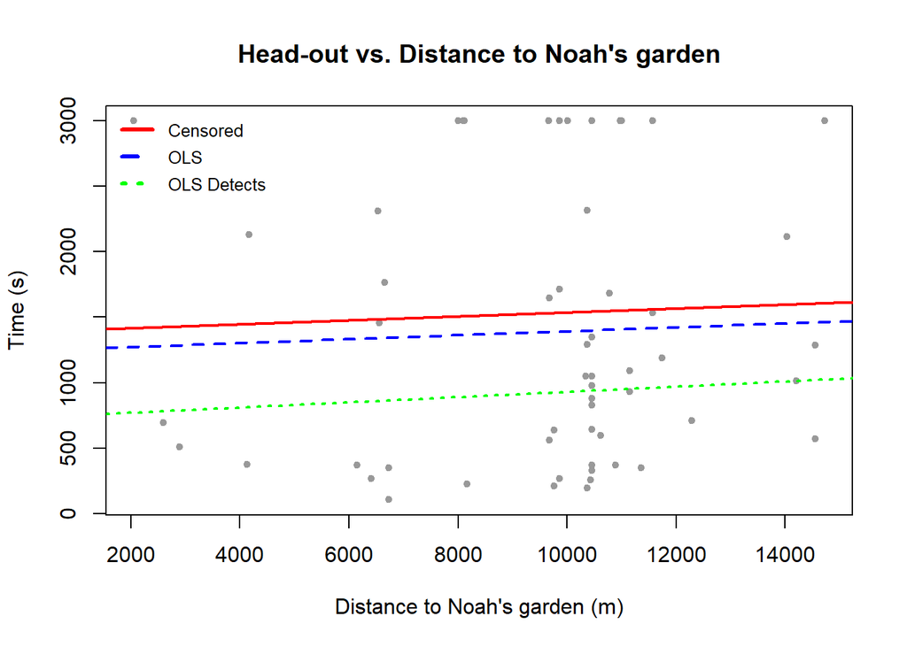

```r
# Plot the results
lineplot <- function() {

  # Add lines
  abline(coef(fit.cen)[1:2], col = "red", lwd = 2)
  abline(coef(fit.OLS), col = "blue", lty = 2, lwd = 2)
  abline(coef(fit.detect), col = "green", lty = 3, lwd = 2)

  # Add legend
  legend(
    "topleft",
    legend = c(
      "Censored",
      "OLS",
      "OLS Detects"
    ),
    lwd = 3 * par("cex"),
    col = c("red", "blue", "green"),
    lty = c(1, 2, 3),
    text.font = 1, bty = "n",
    pt.cex = 1, cex = 0.8, y.intersp = 1.3
  )
}

plot(summary_tracking_complete_no_rep$Distance_Noahs, (summary_tracking_complete_no_rep$Time_head_out_sec_raw), pch = 19, cex = 0.7, col = 'grey60', main = "Head-out vs. Distance to Noah's garden", xlab = "Distance to Noah's garden (m)", ylab = "Time (s)")

lineplot()
```

```r
# ~ Condition
# Censored regression
fit.cen <- censReg((Time_head_out_sec_raw) ~ Condition, data = summary_tracking_complete_no_rep, left = -Inf, right = (3000))

summary(fit.cen)
```

```
Call:
censReg(formula = (Time_head_out_sec_raw) ~ Condition, left = -Inf,
    right = (3000), data = summary_tracking_complete_no_rep)

Observations:
         Total  Left-censored     Uncensored Right-censored
            58              0             45             13

Coefficients:
             Estimate Std. error t value Pr(> t)
(Intercept)  231.5033  1513.8199   0.153   0.878
Condition   1261.2396  1464.5722   0.861   0.389
logSigma       7.1510     0.1132  63.160  <2e-16 ***
---
Signif. codes:  0 '***' 0.001 '**' 0.01 '*' 0.05 '.' 0.1 ' ' 1

Newton-Raphson maximisation, 25 iterations
Return code 8: successive function values within relative tolerance limit (reltol)
Log-likelihood: -400.2079 on 3 Df
```

```r
# Fit a line using OLS regression (linear regression)
fit.OLS <- lm((Time_head_out_sec_raw) ~ Condition, data = summary_tracking_complete_no_rep)

summary(fit.OLS)
```

```
Call:
lm(formula = (Time_head_out_sec_raw) ~ Condition, data = summary_tracking_complete_no_rep)

Residuals:
    Min      1Q  Median      3Q     Max
-1262.6  -881.4  -312.8   909.0  1780.2

Coefficients:
            Estimate Std. Error t value Pr(>|t|)
(Intercept)    549.4     1164.8   0.472    0.639
Condition      812.7     1123.2   0.724    0.472

Residual standard error: 1035 on 56 degrees of freedom
Multiple R-squared:  0.009263,  Adjusted R-squared:  -0.008429
F-statistic: 0.5236 on 1 and 56 DF,  p-value: 0.4723
```

```r
# fit regression only of non-censored data
fit.detect <- lm(Time_head_out_sec_raw ~ Condition, data = summary_tracking_complete_no_rep_detect)

summary(fit.detect)
```

```
Call:
lm(formula = Time_head_out_sec_raw ~ Condition, data = summary_tracking_complete_no_rep_detect)

Residuals:
    Min      1Q  Median      3Q     Max
-822.84 -514.02  -70.43  390.17 1406.96

Coefficients:
            Estimate Std. Error t value Pr(>|t|)
(Intercept)   1497.2     1008.2   1.485    0.145
Condition     -565.5      984.0  -0.575    0.568

Residual standard error: 625.7 on 43 degrees of freedom
Multiple R-squared:  0.007624,  Adjusted R-squared:  -0.01545
F-statistic: 0.3304 on 1 and 43 DF,  p-value: 0.5684
```

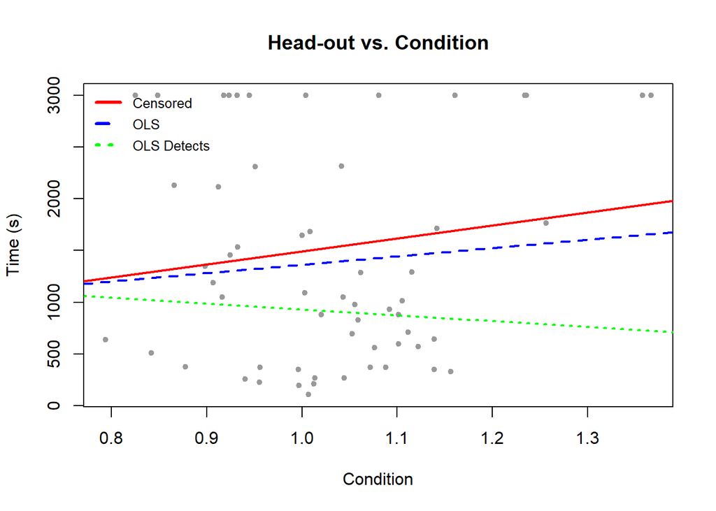

```r
# Plot the results
lineplot <- function() {

  # Add lines
  abline(coef(fit.cen)[1:2], col = "red", lwd = 2)
  abline(coef(fit.OLS), col = "blue", lty = 2, lwd = 2)
  abline(coef(fit.detect), col = "green", lty = 3, lwd = 2)

  # Add legend
  legend(
    "topleft",
    legend = c(
      "Censored",
      "OLS",
      "OLS Detects"
    ),
    lwd = 3 * par("cex"),
    col = c("red", "blue", "green"),
    lty = c(1, 2, 3),
    text.font = 1, bty = "n",
    pt.cex = 1, cex = 0.8, y.intersp = 1.3
  )
}

plot(summary_tracking_complete_no_rep$Condition, (summary_tracking_complete_no_rep$Time_head_out_sec_raw), pch = 19, cex = 0.7, col = 'grey60', main = "Head-out vs. Condition", xlab = "Condition", ylab = "Time (s)")

lineplot()
```

### 7.1.2 Log-transformation

```r
# Censored regression
fit.cen <- censReg(log(Time_head_out_sec_raw) ~ Year_invasion, data = summary_tracking_complete_no_rep, left = -Inf, right = log(3000))

summary(fit.cen)
```

```
Call:
censReg(formula = log(Time_head_out_sec_raw) ~ Year_invasion,
    left = -Inf, right = log(3000), data = summary_tracking_complete_no_rep)

Observations:
         Total  Left-censored     Uncensored Right-censored
            58              0             45             13

Coefficients:
              Estimate Std. error t value Pr(> t)
(Intercept)   78.36739        Inf       0       1
Year_invasion -0.03532        Inf       0       1
logSigma       0.10930        Inf       0       1

Newton-Raphson maximisation, 4 iterations
Return code 8: successive function values within relative tolerance limit (reltol)
Log-likelihood: -82.10584 on 3 Df
```

```r
# Fit a line using OLS regression (linear regression)
fit.OLS <- lm(log(Time_head_out_sec_raw) ~ Year_invasion, data = summary_tracking_complete_no_rep)

summary(fit.OLS)
```

```
Call:
lm(formula = log(Time_head_out_sec_raw) ~ Year_invasion, data = summary_tracking_complete_no_rep)

Residuals:
     Min       1Q   Median       3Q      Max
-2.20876 -0.67712  0.07351  0.81289  1.18276

Coefficients:
               Estimate Std. Error t value Pr(>|t|)
(Intercept)    38.47015  107.84287   0.357    0.723
Year_invasion  -0.01564    0.05340  -0.293    0.771

Residual standard error: 0.917 on 56 degrees of freedom
Multiple R-squared:  0.001529,  Adjusted R-squared:  -0.0163
F-statistic: 0.08576 on 1 and 56 DF,  p-value: 0.7707
```

```r
# fit regression only of non-censored data
fit.detect <- lm(log(Time_head_out_sec_raw) ~ Year_invasion, data = summary_tracking_complete_no_rep_detect)

summary(fit.detect)
```

```
Call:
lm(formula = log(Time_head_out_sec_raw) ~ Year_invasion, data = summary_tracking_complete_no_rep_detect)

Residuals:
    Min      1Q  Median      3Q     Max
-1.9695 -0.6354  0.1074  0.5033  1.2747

Coefficients:
               Estimate Std. Error t value Pr(>|t|)
(Intercept)   -68.15967  112.39334  -0.606    0.547
Year_invasion   0.03700    0.05564   0.665    0.510

Residual standard error: 0.7775 on 43 degrees of freedom
Multiple R-squared:  0.01018,   Adjusted R-squared:  -0.01284
F-statistic: 0.442 on 1 and 43 DF,  p-value: 0.5097
```

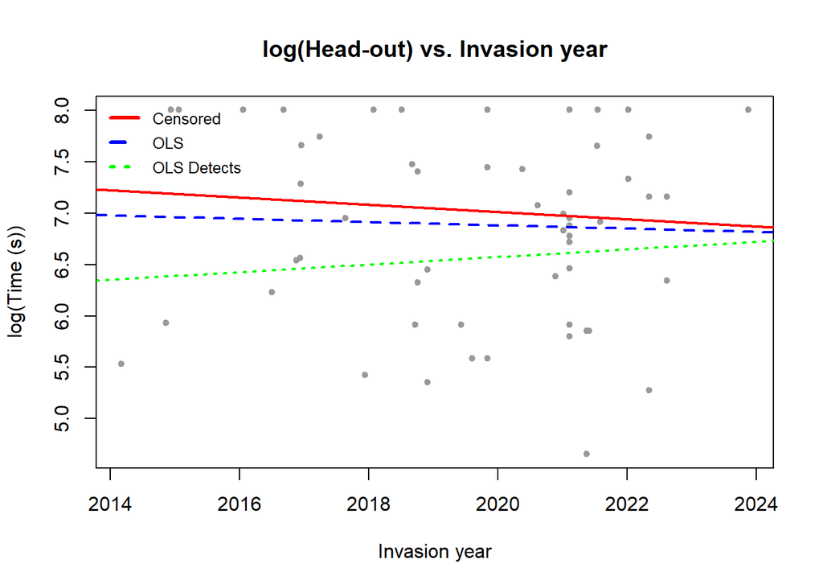

```r
# Plot the results
lineplot <- function() {

  # Add lines
  abline(coef(fit.cen)[1:2], col = "red", lwd = 2)
  abline(coef(fit.OLS), col = "blue", lty = 2, lwd = 2)
  abline(coef(fit.detect), col = "green", lty = 3, lwd = 2)

  # Add legend
  legend(
    "topleft",
    legend = c(
      "Censored",
      "OLS",
      "OLS Detects"
    ),
    lwd = 3 * par("cex"),
    col = c("red", "blue", "green"),
    lty = c(1, 2, 3),
    text.font = 1, bty = "n",
    pt.cex = 1, cex = 0.8, y.intersp = 1.3
  )
}

plot(summary_tracking_complete_no_rep$Year_invasion, log(summary_tracking_complete_no_rep$Time_head_out_sec_raw), pch = 19, cex = 0.7, col = 'grey60', main = "log(Head-out) vs. Invasion year", xlab = "Invasion year", ylab = "log(Time (s))")

lineplot()
```

```r
# ~ Distance to Noah's garden
# Censored regression
fit.cen <- censReg(log(Time_head_out_sec_raw) ~ Distance_Noahs, data = summary_tracking_complete_no_rep, left = -Inf, right = log(3000))

summary(fit.cen)
```

```
Call:
censReg(formula = log(Time_head_out_sec_raw) ~ Distance_Noahs,
    left = -Inf, right = log(3000), data = summary_tracking_complete_no_rep)

Observations:
         Total  Left-censored     Uncensored Right-censored
            58              0             45             13

Coefficients:
                Estimate Std. error t value Pr(> t)
(Intercept)    6.657e+00  5.350e-01  12.443  <2e-16 ***
Distance_Noahs 3.851e-05  5.364e-05   0.718   0.473
logSigma       1.038e-01  1.119e-01   0.927   0.354
---
Signif. codes:  0 '***' 0.001 '**' 0.01 '*' 0.05 '.' 0.1 ' ' 1

Newton-Raphson maximisation, 4 iterations
Return code 8: successive function values within relative tolerance limit (reltol)
Log-likelihood: -81.98694 on 3 Df
```

```r
# Fit a line using OLS regression (linear regression)
fit.OLS <- lm(log(Time_head_out_sec_raw) ~ Distance_Noahs, data = summary_tracking_complete_no_rep)

summary(fit.OLS)
```

```
Call:
lm(formula = log(Time_head_out_sec_raw) ~ Distance_Noahs, data = summary_tracking_complete_no_rep)

Residuals:
     Min       1Q   Median       3Q      Max
-2.13031 -0.68987  0.03492  0.90230  1.39474

Coefficients:
                Estimate Std. Error t value Pr(>|t|)
(Intercept)    6.536e+00  4.297e-01  15.210   <2e-16 ***
Distance_Noahs 3.692e-05  4.309e-05   0.857    0.395
---
Signif. codes:  0 '***' 0.001 '**' 0.01 '*' 0.05 '.' 0.1 ' ' 1

Residual standard error: 0.9118 on 56 degrees of freedom
Multiple R-squared:  0.01294,   Adjusted R-squared:  -0.004689
F-statistic: 0.734 on 1 and 56 DF,  p-value: 0.3953
```

```r
# fit regression only of non-censored data
fit.detect <- lm(log(Time_head_out_sec_raw) ~ Distance_Noahs, data = summary_tracking_complete_no_rep_detect)

summary(fit.detect)
```

```
Call:
lm(formula = log(Time_head_out_sec_raw) ~ Distance_Noahs, data = summary_tracking_complete_no_rep_detect)

Residuals:
    Min      1Q  Median      3Q     Max
-1.7762 -0.5779  0.1303  0.5580  1.3576

Coefficients:
                Estimate Std. Error t value Pr(>|t|)
(Intercept)    6.108e+00  4.111e-01  14.857   <2e-16 ***
Distance_Noahs 4.792e-05  4.121e-05   1.163    0.251
---
Signif. codes:  0 '***' 0.001 '**' 0.01 '*' 0.05 '.' 0.1 ' ' 1

Residual standard error: 0.7695 on 43 degrees of freedom
Multiple R-squared:  0.03049,   Adjusted R-squared:  0.007939
F-statistic: 1.352 on 1 and 43 DF,  p-value: 0.2513
```

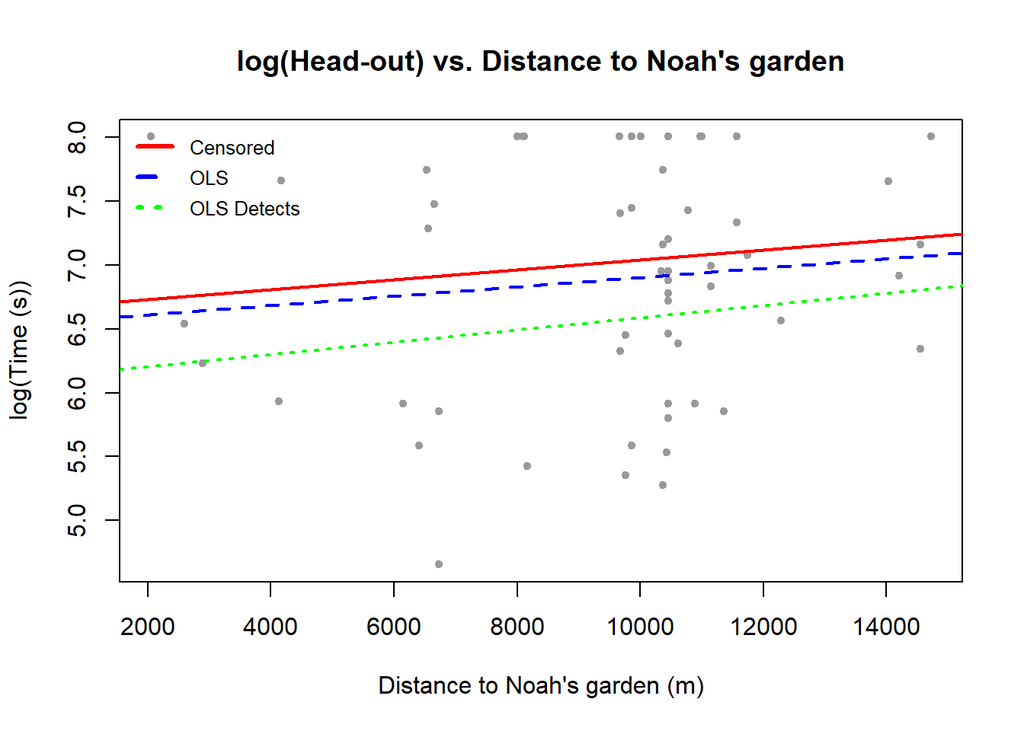

```r
# Plot the results
lineplot <- function() {

  # Add lines
  abline(coef(fit.cen)[1:2], col = "red", lwd = 2)
  abline(coef(fit.OLS), col = "blue", lty = 2, lwd = 2)
  abline(coef(fit.detect), col = "green", lty = 3, lwd = 2)

  # Add legend
  legend(
    "topleft",
    legend = c(
      "Censored",
      "OLS",
      "OLS Detects"
    ),
    lwd = 3 * par("cex"),
    col = c("red", "blue", "green"),
    lty = c(1, 2, 3),
    text.font = 1, bty = "n",
    pt.cex = 1, cex = 0.8, y.intersp = 1.3
  )
}

plot(summary_tracking_complete_no_rep$Distance_Noahs, log(summary_tracking_complete_no_rep$Time_head_out_sec_raw), pch = 19, cex = 0.7, col = 'grey60', main = "log(Head-out) vs. Distance to Noah's garden", xlab = "Distance to Noah's garden (m)", ylab = "log(Time (s))")

lineplot()
```

```r
# ~ Condition
# Censored regression
fit.cen <- censReg(log(Time_head_out_sec_raw) ~ Condition, data = summary_tracking_complete_no_rep, left = -Inf, right = log(3000))

summary(fit.cen)
```

```
Call:
censReg(formula = log(Time_head_out_sec_raw) ~ Condition, left = -Inf,
    right = log(3000), data = summary_tracking_complete_no_rep)

Observations:
         Total  Left-censored     Uncensored Right-censored
            58              0             45             13

Coefficients:
            Estimate Std. error t value  Pr(> t)
(Intercept)   5.9034     1.3325   4.430 9.41e-06 ***
Condition     1.0926     1.2899   0.847    0.397
logSigma      0.1057     0.1118   0.945    0.345
---
Signif. codes:  0 '***' 0.001 '**' 0.01 '*' 0.05 '.' 0.1 ' ' 1

Newton-Raphson maximisation, 4 iterations
Return code 8: successive function values within relative tolerance limit (reltol)
Log-likelihood: -81.88201 on 3 Df
```

```r
# Fit a line using OLS regression (linear regression)
fit.OLS <- lm(log(Time_head_out_sec_raw) ~ Condition, data = summary_tracking_complete_no_rep)

summary(fit.OLS)
```

```
Call:
lm(formula = log(Time_head_out_sec_raw) ~ Condition, data = summary_tracking_complete_no_rep)

Residuals:
     Min       1Q   Median       3Q      Max
-2.22055 -0.60349  0.08833  0.87373  1.24953

Coefficients:
            Estimate Std. Error t value Pr(>|t|)
(Intercept)   6.2232     1.0286   6.050 1.26e-07 ***
Condition     0.6469     0.9918   0.652    0.517
---
Signif. codes:  0 '***' 0.001 '**' 0.01 '*' 0.05 '.' 0.1 ' ' 1

Residual standard error: 0.9142 on 56 degrees of freedom
Multiple R-squared:  0.00754,   Adjusted R-squared:  -0.01018
F-statistic: 0.4254 on 1 and 56 DF,  p-value: 0.5169
```

```r
# fit regression only of non-censored data
fit.detect <- lm(log(Time_head_out_sec_raw) ~ Condition, data = summary_tracking_complete_no_rep_detect)

summary(fit.detect)
```

```
Call:
lm(formula = log(Time_head_out_sec_raw) ~ Condition, data = summary_tracking_complete_no_rep_detect)

Residuals:
    Min      1Q  Median      3Q     Max
-1.9158 -0.6671  0.1604  0.6119  1.1849

Coefficients:
            Estimate Std. Error t value Pr(>|t|)
(Intercept)   6.7853     1.2587   5.391 2.79e-06 ***
Condition    -0.2141     1.2285  -0.174    0.862
---
Signif. codes:  0 '***' 0.001 '**' 0.01 '*' 0.05 '.' 0.1 ' ' 1

Residual standard error: 0.7812 on 43 degrees of freedom
Multiple R-squared:  0.0007062, Adjusted R-squared:  -0.02253
F-statistic: 0.03039 on 1 and 43 DF,  p-value: 0.8624
```

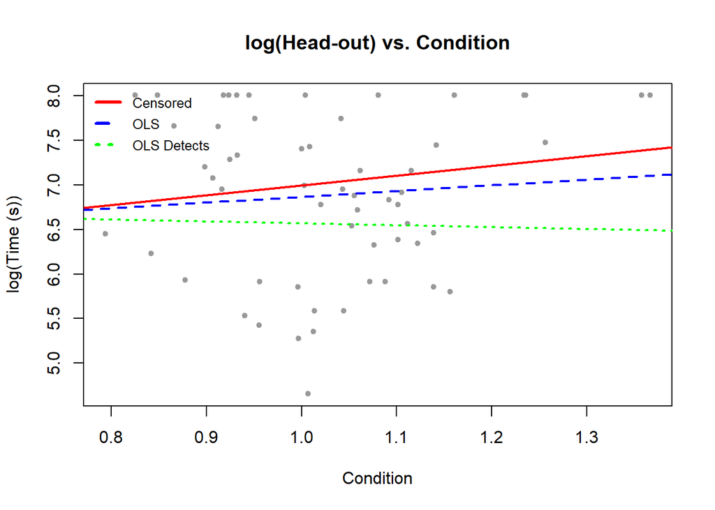

```r
# Plot the results
lineplot <- function() {

  # Add lines
  abline(coef(fit.cen)[1:2], col = "red", lwd = 2)
  abline(coef(fit.OLS), col = "blue", lty = 2, lwd = 2)
  abline(coef(fit.detect), col = "green", lty = 3, lwd = 2)

  # Add legend
  legend(
    "topleft",
    legend = c(
      "Censored",
      "OLS",
      "OLS Detects"
    ),
    lwd = 3 * par("cex"),
    col = c("red", "blue", "green"),
    lty = c(1, 2, 3),
    text.font = 1, bty = "n",
    pt.cex = 1, cex = 0.8, y.intersp = 1.3
  )
}

plot(summary_tracking_complete_no_rep$Condition, log(summary_tracking_complete_no_rep$Time_head_out_sec_raw), pch = 19, cex = 0.7, col = 'grey60', main = "log(Head-out) vs. Condition", xlab = "Condition", ylab = "log(Time (s))")

lineplot()
```

## 7.2 Body-out

### 7.2.1 No log-transformation

```r
# ~ Invasion year
# Censored regression
fit.cen <- censReg((Time_body_out_sec_raw) ~ Year_invasion, data = summary_tracking_complete_no_rep, left = -Inf, right = (3000))

summary(fit.cen)
```

```
Call:
censReg(formula = (Time_body_out_sec_raw) ~ Year_invasion, left = -Inf,
    right = (3000), data = summary_tracking_complete_no_rep)

Observations:
         Total  Left-censored     Uncensored Right-censored
            58              0             44             14

Coefficients:
               Estimate Std. error t value Pr(> t)
(Intercept)   25942.530        Inf       0       1
Year_invasion   -11.951        Inf       0       1
logSigma          7.098        Inf       0       1

Newton-Raphson maximisation, 9 iterations
Return code 8: successive function values within relative tolerance limit (reltol)
Log-likelihood: -389.7635 on 3 Df
```

```r
# Fit a line using OLS regression (linear regression)
fit.OLS <- lm((Time_body_out_sec_raw) ~ Year_invasion, data = summary_tracking_complete_no_rep)

summary(fit.OLS)
```

```
Call:
lm(formula = (Time_body_out_sec_raw) ~ Year_invasion, data = summary_tracking_complete_no_rep)

Residuals:
    Min      1Q  Median      3Q     Max
-1458.0  -808.2  -171.7  1104.2  1399.1

Coefficients:
               Estimate Std. Error t value Pr(>|t|)
(Intercept)    25935.12  113733.19   0.228    0.820
Year_invasion    -12.02      56.31  -0.214    0.832

Residual standard error: 967.1 on 56 degrees of freedom
Multiple R-squared:  0.0008134, Adjusted R-squared:  -0.01703
F-statistic: 0.04559 on 1 and 56 DF,  p-value: 0.8317
```

```r
# fit regression only of non-censored data
fit.detect <- lm((Time_body_out_sec_raw) ~ Year_invasion, data = summary_tracking_complete_no_rep_detect)

summary(fit.detect)
```

```
Call:
lm(formula = (Time_body_out_sec_raw) ~ Year_invasion, data = summary_tracking_complete_no_rep_detect)

Residuals:
    Min      1Q  Median      3Q     Max
-1173.2  -471.8  -145.7   499.6  1645.0

Coefficients:
                Estimate Std. Error t value Pr(>|t|)
(Intercept)   -109873.66  101884.04  -1.078    0.287
Year_invasion      55.02      50.44   1.091    0.281

Residual standard error: 704.8 on 43 degrees of freedom
Multiple R-squared:  0.02693,   Adjusted R-squared:  0.004296
F-statistic:  1.19 on 1 and 43 DF,  p-value: 0.2814
```

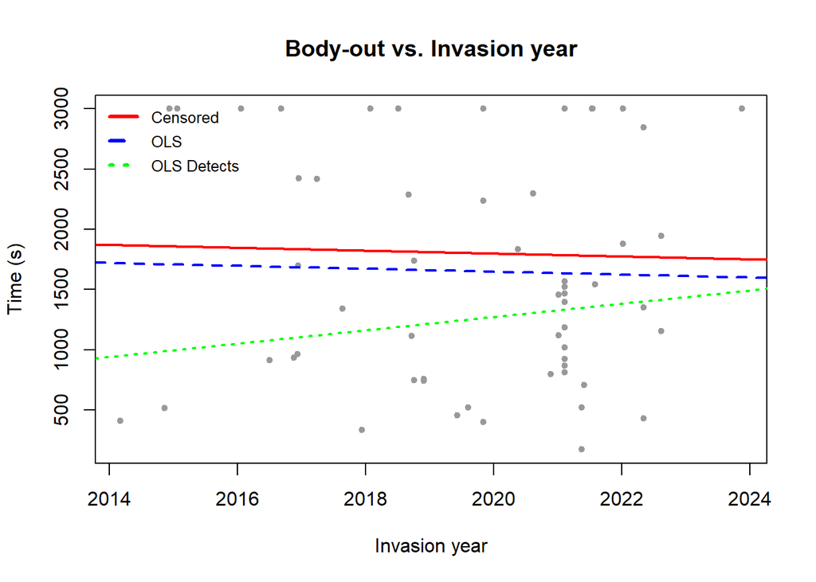

```r
# Plot the results
lineplot <- function() {

  # Add lines
  abline(coef(fit.cen)[1:2], col = "red", lwd = 2)
  abline(coef(fit.OLS), col = "blue", lty = 2, lwd = 2)
  abline(coef(fit.detect), col = "green", lty = 3, lwd = 2)

  # Add legend
  legend(
    "topleft",
    legend = c(
      "Censored",
      "OLS",
      "OLS Detects"
    ),
    lwd = 3 * par("cex"),
    col = c("red", "blue", "green"),
    lty = c(1, 2, 3),
    text.font = 1, bty = "n",
    pt.cex = 1, cex = 0.8, y.intersp = 1.3
  )
}

plot(summary_tracking_complete_no_rep$Year_invasion, (summary_tracking_complete_no_rep$Time_body_out_sec_raw), pch = 19, cex = 0.7, col = 'grey60', main = "Body-out vs. Invasion year", xlab = "Invasion year", ylab = "Time (s)")

lineplot()
```

```r
# ~ Distance to Noah's garden
# Censored regression
fit.cen <- censReg((Time_body_out_sec_raw) ~ Distance_Noahs, data = summary_tracking_complete_no_rep, left = -Inf, right = (3000))

summary(fit.cen)
```

```
Call:
censReg(formula = (Time_body_out_sec_raw) ~ Distance_Noahs, left = -Inf,
    right = (3000), data = summary_tracking_complete_no_rep)

Observations:
         Total  Left-censored     Uncensored Right-censored
            58              0             44             14

Coefficients:
                Estimate Std. error t value Pr(> t)
(Intercept)    1.315e+03  5.798e+02   2.268  0.0233 *
Distance_Noahs 5.117e-02  5.829e-02   0.878  0.3801
logSigma       7.091e+00  1.146e-01  61.871  <2e-16 ***
---
Signif. codes:  0 '***' 0.001 '**' 0.01 '*' 0.05 '.' 0.1 ' ' 1

Newton-Raphson maximisation, 9 iterations
Return code 8: successive function values within relative tolerance limit (reltol)
Log-likelihood: -389.4294 on 3 Df
```

```r
# Fit a line using OLS regression (linear regression)
fit.OLS <- lm((Time_body_out_sec_raw) ~ Distance_Noahs, data = summary_tracking_complete_no_rep)

summary(fit.OLS)
```

```
Call:
lm(formula = (Time_body_out_sec_raw) ~ Distance_Noahs, data = summary_tracking_complete_no_rep)

Residuals:
    Min      1Q  Median      3Q     Max
-1357.8  -860.0  -274.4  1097.5  1667.4

Coefficients:
                Estimate Std. Error t value Pr(>|t|)
(Intercept)    1.246e+03  4.525e+02   2.753  0.00794 **
Distance_Noahs 4.238e-02  4.537e-02   0.934  0.35427
---
Signif. codes:  0 '***' 0.001 '**' 0.01 '*' 0.05 '.' 0.1 ' ' 1

Residual standard error: 960 on 56 degrees of freedom
Multiple R-squared:  0.01534,   Adjusted R-squared:  -0.002242
F-statistic: 0.8725 on 1 and 56 DF,  p-value: 0.3543
```

```r
# fit regression only of non-censored data
fit.detect <- lm((Time_body_out_sec_raw) ~ Distance_Noahs, data = summary_tracking_complete_no_rep_detect)

summary(fit.detect)
```

```
Call:
lm(formula = (Time_body_out_sec_raw) ~ Distance_Noahs, data = summary_tracking_complete_no_rep_detect)

Residuals:
   Min     1Q Median     3Q    Max
-932.0 -517.2 -124.1  407.6 1540.8

Coefficients:
                Estimate Std. Error t value Pr(>|t|)
(Intercept)    734.73398  372.41373   1.973    0.055 .
Distance_Noahs   0.05504    0.03733   1.474    0.148
---
Signif. codes:  0 '***' 0.001 '**' 0.01 '*' 0.05 '.' 0.1 ' ' 1

Residual standard error: 697.1 on 43 degrees of freedom
Multiple R-squared:  0.04812,   Adjusted R-squared:  0.02599
F-statistic: 2.174 on 1 and 43 DF,  p-value: 0.1477
```

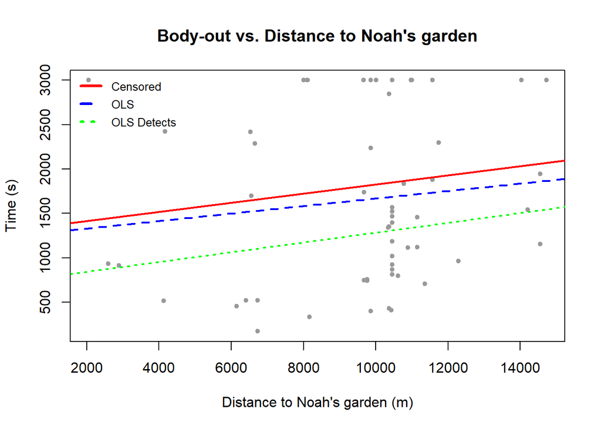

```r
# Plot the results
lineplot <- function() {

  # Add lines
  abline(coef(fit.cen)[1:2], col = "red", lwd = 2)
  abline(coef(fit.OLS), col = "blue", lty = 2, lwd = 2)
  abline(coef(fit.detect), col = "green", lty = 3, lwd = 2)

  # Add legend
  legend(
    "topleft",
    legend = c(
      "Censored",
      "OLS",
      "OLS Detects"
    ),
    lwd = 3 * par("cex"),
    col = c("red", "blue", "green"),
    lty = c(1, 2, 3),
    text.font = 1, bty = "n",
    pt.cex = 1, cex = 0.8, y.intersp = 1.3
  )
}

plot(summary_tracking_complete_no_rep$Distance_Noahs, (summary_tracking_complete_no_rep$Time_body_out_sec_raw), pch = 19, cex = 0.7, col = 'grey60', main = "Body-out vs. Distance to Noah's garden", xlab = "Distance to Noah's garden (m)", ylab = "Time (s)")

lineplot()
```

```r
# ~ Condition
# Censored regression
fit.cen <- censReg((Time_body_out_sec_raw) ~ Condition, data = summary_tracking_complete_no_rep, left = -Inf, right = (3000))

summary(fit.cen)
```

```
Call:
censReg(formula = (Time_body_out_sec_raw) ~ Condition, left = -Inf,
    right = (3000), data = summary_tracking_complete_no_rep)

Observations:
         Total  Left-censored     Uncensored Right-censored
            58              0             44             14

Coefficients:
             Estimate Std. error t value Pr(> t)
(Intercept)  648.7971  1439.3332   0.451   0.652
Condition   1124.0041  1392.1422   0.807   0.419
logSigma       7.0935     0.1146  61.912  <2e-16 ***
---
Signif. codes:  0 '***' 0.001 '**' 0.01 '*' 0.05 '.' 0.1 ' ' 1

Newton-Raphson maximisation, 23 iterations
Return code 8: successive function values within relative tolerance limit (reltol)
Log-likelihood: -389.4813 on 3 Df
```

```r
# Fit a line using OLS regression (linear regression)
fit.OLS <- lm((Time_body_out_sec_raw) ~ Condition, data = summary_tracking_complete_no_rep)

summary(fit.OLS)
```

```
Call:
lm(formula = (Time_body_out_sec_raw) ~ Condition, data = summary_tracking_complete_no_rep)

Residuals:
    Min      1Q  Median      3Q     Max
-1460.9  -796.8  -183.3  1042.6  1504.7

Coefficients:
            Estimate Std. Error t value Pr(>|t|)
(Intercept)    866.9     1083.3   0.800    0.427
Condition      761.8     1044.6   0.729    0.469

Residual standard error: 962.9 on 56 degrees of freedom
Multiple R-squared:  0.009408,  Adjusted R-squared:  -0.008281
F-statistic: 0.5319 on 1 and 56 DF,  p-value: 0.4689
```

```r
# fit regression only of non-censored data
fit.detect <- lm((Time_body_out_sec_raw) ~ Condition, data = summary_tracking_complete_no_rep_detect)

summary(fit.detect)
```

```
Call:
lm(formula = (Time_body_out_sec_raw) ~ Condition, data = summary_tracking_complete_no_rep_detect)

Residuals:
    Min      1Q  Median      3Q     Max
-1093.0  -504.3  -118.5   409.4  1705.7

Coefficients:
            Estimate Std. Error t value Pr(>|t|)
(Intercept)   1567.0     1150.2   1.362    0.180
Condition     -298.9     1122.6  -0.266    0.791

Residual standard error: 713.9 on 43 degrees of freedom
Multiple R-squared:  0.001646,  Adjusted R-squared:  -0.02157
F-statistic: 0.0709 on 1 and 43 DF,  p-value: 0.7913
```

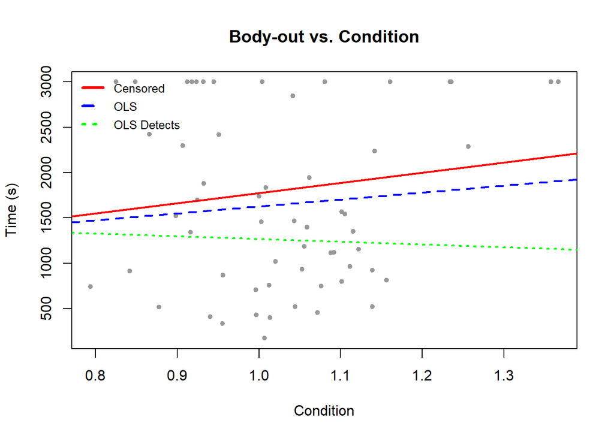

```r
# Plot the results
lineplot <- function() {

  # Add lines
  abline(coef(fit.cen)[1:2], col = "red", lwd = 2)
  abline(coef(fit.OLS), col = "blue", lty = 2, lwd = 2)
  abline(coef(fit.detect), col = "green", lty = 3, lwd = 2)

  # Add legend
  legend(
    "topleft",
    legend = c(
      "Censored",
      "OLS",
      "OLS Detects"
    ),
    lwd = 3 * par("cex"),
    col = c("red", "blue", "green"),
    lty = c(1, 2, 3),
    text.font = 1, bty = "n",
    pt.cex = 1, cex = 0.8, y.intersp = 1.3
  )
}

plot(summary_tracking_complete_no_rep$Condition, (summary_tracking_complete_no_rep$Time_body_out_sec_raw), pch = 19, cex = 0.7, col = 'grey60', main = "Body-out vs. Condition", xlab = "Condition", ylab = "Time (s)")

lineplot()
```

### 7.2.2 Log-transformation

```r
# Censored regression
fit.cen <- censReg(log(Time_body_out_sec_raw) ~ Year_invasion, data = summary_tracking_complete_no_rep, left = -Inf, right = log(3000))

summary(fit.cen)
```

```
Call:
censReg(formula = log(Time_body_out_sec_raw) ~ Year_invasion,
    left = -Inf, right = log(3000), data = summary_tracking_complete_no_rep)

Observations:
         Total  Left-censored     Uncensored Right-censored
            58              0             44             14

Coefficients:
               Estimate Std. error t value Pr(> t)
(Intercept)   20.761570        Inf       0       1
Year_invasion -0.006655        Inf       0       1
logSigma      -0.122283        Inf       0       1

Newton-Raphson maximisation, 5 iterations
Return code 8: successive function values within relative tolerance limit (reltol)
Log-likelihood: -70.96592 on 3 Df
```

```r
# Fit a line using OLS regression (linear regression)
fit.OLS <- lm(log(Time_body_out_sec_raw) ~ Year_invasion, data = summary_tracking_complete_no_rep)

summary(fit.OLS)
```

```
Call:
lm(formula = log(Time_body_out_sec_raw) ~ Year_invasion, data = summary_tracking_complete_no_rep)

Residuals:
    Min      1Q  Median      3Q     Max
-2.0539 -0.4865  0.0825  0.7078  0.8299

Coefficients:
               Estimate Std. Error t value Pr(>|t|)
(Intercept)   -2.477176  84.184041  -0.029    0.977
Year_invasion  0.004791   0.041682   0.115    0.909

Residual standard error: 0.7158 on 56 degrees of freedom
Multiple R-squared:  0.0002359, Adjusted R-squared:  -0.01762
F-statistic: 0.01321 on 1 and 56 DF,  p-value: 0.9089
```

```r
# fit regression only of non-censored data
fit.detect <- lm(log(Time_body_out_sec_raw) ~ Year_invasion, data = summary_tracking_complete_no_rep_detect)

summary(fit.detect)
```

```
Call:
lm(formula = log(Time_body_out_sec_raw) ~ Year_invasion, data = summary_tracking_complete_no_rep_detect)

Residuals:
     Min       1Q   Median       3Q      Max
-1.89061 -0.32730  0.04786  0.46298  0.97366

Coefficients:
               Estimate Std. Error t value Pr(>|t|)
(Intercept)   -96.15692   91.61523  -1.050    0.300
Year_invasion   0.05105    0.04536   1.126    0.267

Residual standard error: 0.6338 on 43 degrees of freedom
Multiple R-squared:  0.02862,   Adjusted R-squared:  0.006031
F-statistic: 1.267 on 1 and 43 DF,  p-value: 0.2666
```

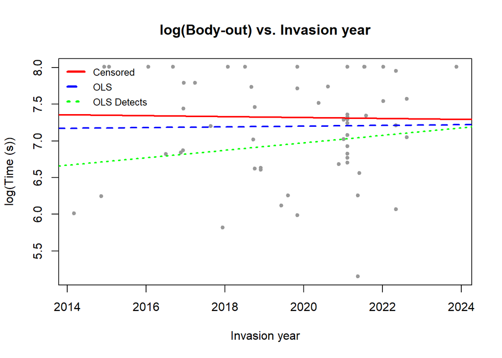

```r
# Plot the results
lineplot <- function() {

  # Add lines
  abline(coef(fit.cen)[1:2], col = "red", lwd = 2)
  abline(coef(fit.OLS), col = "blue", lty = 2, lwd = 2)
  abline(coef(fit.detect), col = "green", lty = 3, lwd = 2)

  # Add legend
  legend(
    "topleft",
    legend = c(
      "Censored",
      "OLS",
      "OLS Detects"
    ),
    lwd = 3 * par("cex"),
    col = c("red", "blue", "green"),
    lty = c(1, 2, 3),
    text.font = 1, bty = "n",
    pt.cex = 1, cex = 0.8, y.intersp = 1.3
  )
}

plot(summary_tracking_complete_no_rep$Year_invasion, log(summary_tracking_complete_no_rep$Time_body_out_sec_raw), pch = 19, cex = 0.7, col = 'grey60', main = "log(Body-out) vs. Invasion year", xlab = "Invasion year", ylab = "log(Time (s))")

lineplot()
```

```r
# ~ Distance to Noah's garden
# Censored regression
fit.cen <- censReg(log(Time_body_out_sec_raw) ~ Distance_Noahs, data = summary_tracking_complete_no_rep, left = -Inf, right = log(3000))

summary(fit.cen)
```

```
Call:
censReg(formula = log(Time_body_out_sec_raw) ~ Distance_Noahs,
    left = -Inf, right = log(3000), data = summary_tracking_complete_no_rep)

Observations:
         Total  Left-censored     Uncensored Right-censored
            58              0             44             14

Coefficients:
                 Estimate Std. error t value Pr(> t)
(Intercept)     6.776e+00  4.198e-01  16.140  <2e-16 ***
Distance_Noahs  5.682e-05  4.225e-05   1.345   0.179
logSigma       -1.421e-01  1.133e-01  -1.255   0.210
---
Signif. codes:  0 '***' 0.001 '**' 0.01 '*' 0.05 '.' 0.1 ' ' 1

Newton-Raphson maximisation, 5 iterations
Return code 8: successive function values within relative tolerance limit (reltol)
Log-likelihood: -70.08435 on 3 Df
```

```r
# Fit a line using OLS regression (linear regression)
fit.OLS <- lm(log(Time_body_out_sec_raw) ~ Distance_Noahs, data = summary_tracking_complete_no_rep)

summary(fit.OLS)
```

```
Call:
lm(formula = log(Time_body_out_sec_raw) ~ Distance_Noahs, data = summary_tracking_complete_no_rep)

Residuals:
     Min       1Q   Median       3Q      Max
-1.90688 -0.52220  0.00587  0.70238  1.17402

Coefficients:
                Estimate Std. Error t value Pr(>|t|)
(Intercept)    6.732e+00  3.311e-01  20.333   <2e-16 ***
Distance_Noahs 4.871e-05  3.320e-05   1.467    0.148
---
Signif. codes:  0 '***' 0.001 '**' 0.01 '*' 0.05 '.' 0.1 ' ' 1

Residual standard error: 0.7025 on 56 degrees of freedom
Multiple R-squared:  0.03702,   Adjusted R-squared:  0.01982
F-statistic: 2.153 on 1 and 56 DF,  p-value: 0.1479
```

```r
# fit regression only of non-censored data
fit.detect <- lm(log(Time_body_out_sec_raw) ~ Distance_Noahs, data = summary_tracking_complete_no_rep_detect)

summary(fit.detect)
```

```
Call:
lm(formula = log(Time_body_out_sec_raw) ~ Distance_Noahs, data = summary_tracking_complete_no_rep_detect)

Residuals:
     Min       1Q   Median       3Q      Max
-1.63298 -0.35166  0.05759  0.33744  1.16705

Coefficients:
                Estimate Std. Error t value Pr(>|t|)
(Intercept)    6.363e+00  3.299e-01  19.286   <2e-16 ***
Distance_Noahs 6.292e-05  3.307e-05   1.902   0.0638 .
---
Signif. codes:  0 '***' 0.001 '**' 0.01 '*' 0.05 '.' 0.1 ' ' 1

Residual standard error: 0.6176 on 43 degrees of freedom
Multiple R-squared:  0.07764,   Adjusted R-squared:  0.05619
F-statistic: 3.619 on 1 and 43 DF,  p-value: 0.06382
```

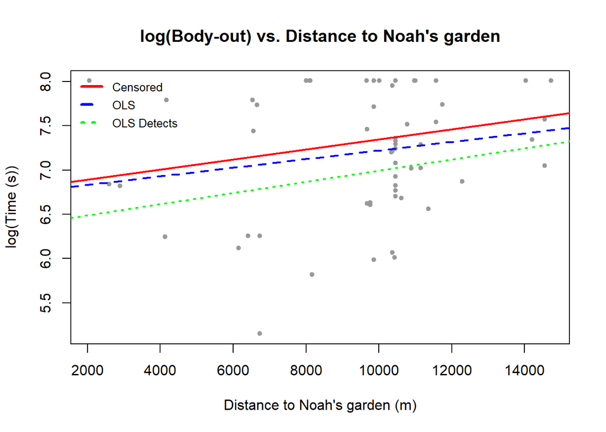

```r
# Plot the results
lineplot <- function() {

  # Add lines
  abline(coef(fit.cen)[1:2], col = "red", lwd = 2)
  abline(coef(fit.OLS), col = "blue", lty = 2, lwd = 2)
  abline(coef(fit.detect), col = "green", lty = 3, lwd = 2)

  # Add legend
  legend(
    "topleft",
    legend = c(
      "Censored",
      "OLS",
      "OLS Detects"
    ),
    lwd = 3 * par("cex"),
    col = c("red", "blue", "green"),
    lty = c(1, 2, 3),
    text.font = 1, bty = "n",
    pt.cex = 1, cex = 0.8, y.intersp = 1.3
  )
}

plot(summary_tracking_complete_no_rep$Distance_Noahs, log(summary_tracking_complete_no_rep$Time_body_out_sec_raw), pch = 19, cex = 0.7, col = 'grey60', main = "log(Body-out) vs. Distance to Noah's garden", xlab = "Distance to Noah's garden (m)", ylab = "log(Time (s))")

lineplot()
```

```r
# ~ Condition
# Censored regression
fit.cen <- censReg(log(Time_body_out_sec_raw) ~ Condition, data = summary_tracking_complete_no_rep, left = -Inf, right = log(3000))

summary(fit.cen)
```

```
Call:
censReg(formula = log(Time_body_out_sec_raw) ~ Condition, left = -Inf,
    right = log(3000), data = summary_tracking_complete_no_rep)

Observations:
         Total  Left-censored     Uncensored Right-censored
            58              0             44             14

Coefficients:
            Estimate Std. error t value  Pr(> t)
(Intercept)   6.3768     1.0609   6.011 1.85e-09 ***
Condition     0.9178     1.0267   0.894    0.371
logSigma     -0.1290     0.1132  -1.139    0.255
---
Signif. codes:  0 '***' 0.001 '**' 0.01 '*' 0.05 '.' 0.1 ' ' 1

Newton-Raphson maximisation, 5 iterations
Return code 1: gradient close to zero (gradtol)
Log-likelihood: -70.57256 on 3 Df
```

```r
# Fit a line using OLS regression (linear regression)
fit.OLS <- lm(log(Time_body_out_sec_raw) ~ Condition, data = summary_tracking_complete_no_rep)

summary(fit.OLS)
```

```
Call:
lm(formula = log(Time_body_out_sec_raw) ~ Condition, data = summary_tracking_complete_no_rep)

Residuals:
     Min       1Q   Median       3Q      Max
-2.03164 -0.44516  0.09028  0.63308  0.93207

Coefficients:
            Estimate Std. Error t value Pr(>|t|)
(Intercept)   6.5726     0.8010   8.205 3.56e-11 ***
Condition     0.6082     0.7724   0.787    0.434
---
Signif. codes:  0 '***' 0.001 '**' 0.01 '*' 0.05 '.' 0.1 ' ' 1

Residual standard error: 0.712 on 56 degrees of freedom
Multiple R-squared:  0.01095,   Adjusted R-squared:  -0.006711
F-statistic:  0.62 on 1 and 56 DF,  p-value: 0.4344
```

```r
# fit regression only of non-censored data
fit.detect <- lm(log(Time_body_out_sec_raw) ~ Condition, data = summary_tracking_complete_no_rep_detect)

summary(fit.detect)
```

```
Call:
lm(formula = log(Time_body_out_sec_raw) ~ Condition, data = summary_tracking_complete_no_rep_detect)

Residuals:
     Min       1Q   Median       3Q      Max
-1.81063 -0.33140  0.04695  0.48601  1.05574

Coefficients:
            Estimate Std. Error t value Pr(>|t|)
(Intercept)   6.8224     1.0358   6.586 5.12e-08 ***
Condition     0.1406     1.0110   0.139     0.89
---
Signif. codes:  0 '***' 0.001 '**' 0.01 '*' 0.05 '.' 0.1 ' ' 1

Residual standard error: 0.6429 on 43 degrees of freedom
Multiple R-squared:  0.0004493, Adjusted R-squared:  -0.0228
F-statistic: 0.01933 on 1 and 43 DF,  p-value: 0.8901
```

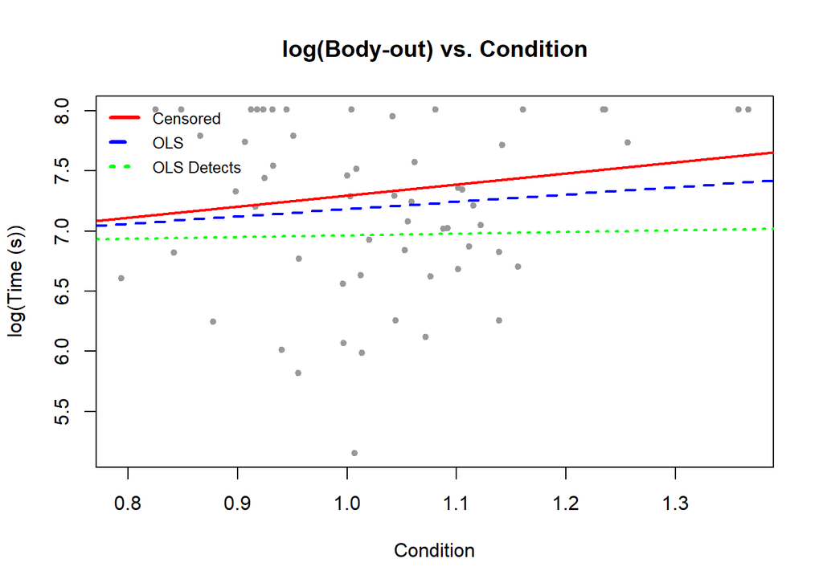

```r
# Plot the results
lineplot <- function() {

  # Add lines
  abline(coef(fit.cen)[1:2], col = "red", lwd = 2)
  abline(coef(fit.OLS), col = "blue", lty = 2, lwd = 2)
  abline(coef(fit.detect), col = "green", lty = 3, lwd = 2)

  # Add legend
  legend(
    "topleft",
    legend = c(
      "Censored",
      "OLS",
      "OLS Detects"
    ),
    lwd = 3 * par("cex"),
    col = c("red", "blue", "green"),
    lty = c(1, 2, 3),
    text.font = 1, bty = "n",
    pt.cex = 1, cex = 0.8, y.intersp = 1.3
  )
}

plot(summary_tracking_complete_no_rep$Condition, log(summary_tracking_complete_no_rep$Time_body_out_sec_raw), pch = 19, cex = 0.7, col = 'grey60', main = "log(Body-out) vs. Condition", xlab = "Condition", ylab = "log(Time (s))")

lineplot()
```

## 7.3 Visual exploration

### 7.3.1 No log-transformation

```r
# Create filtered data frame for this part of the analysis
summary_tracking_complete_no_rep_detect <- summary_tracking_complete_no_rep[summary_tracking_complete_no_rep$Visual_exp != 0, ]

# ~ Invasion year
# Censored regression
fit.cen <- censReg((Visual_exp) ~ Year_invasion, data = summary_tracking_complete_no_rep, left = 0, right = Inf)

summary(fit.cen)
```

```
Call:
censReg(formula = (Visual_exp) ~ Year_invasion, left = 0, right = Inf,
    data = summary_tracking_complete_no_rep)

Observations:
         Total  Left-censored     Uncensored Right-censored
            58             13             45              0

Coefficients:
                Estimate Std. error t value Pr(> t)
(Intercept)   -6.391e+04  3.616e+04  -1.768  0.0771 .
Year_invasion  3.176e+01  1.790e+01   1.774  0.0761 .
logSigma       5.682e+00  1.108e-01  51.260  <2e-16 ***
---
Signif. codes:  0 '***' 0.001 '**' 0.01 '*' 0.05 '.' 0.1 ' ' 1

Newton-Raphson maximisation, 150 iterations
Return code 4: Iteration limit exceeded (iterlim)
Log-likelihood: -332.0988 on 3 Df
```

```r
# Fit a line using OLS regression (linear regression)
fit.OLS <- lm((Visual_exp) ~ Year_invasion, data = summary_tracking_complete_no_rep)

summary(fit.OLS)
```

```
Call:
lm(formula = (Visual_exp) ~ Year_invasion, data = summary_tracking_complete_no_rep)

Residuals:
    Min      1Q  Median      3Q     Max
-395.54 -152.15  -65.72  158.50  813.27

Coefficients:
               Estimate Std. Error t value Pr(>|t|)
(Intercept)   -62234.34   28732.06  -2.166   0.0346 *
Year_invasion     30.95      14.23   2.175   0.0338 *
---
Signif. codes:  0 '***' 0.001 '**' 0.01 '*' 0.05 '.' 0.1 ' ' 1

Residual standard error: 244.3 on 56 degrees of freedom
Multiple R-squared:  0.07791,   Adjusted R-squared:  0.06145
F-statistic: 4.732 on 1 and 56 DF,  p-value: 0.03385
```

```r
# fit regression only of non-censored data
fit.detect <- lm(Visual_exp ~ Year_invasion, data = summary_tracking_complete_no_rep_detect)

summary(fit.detect)
```

```
Call:
lm(formula = Visual_exp ~ Year_invasion, data = summary_tracking_complete_no_rep_detect)

Residuals:
    Min      1Q  Median      3Q     Max
-358.38 -185.38   -8.64  134.04  741.24

Coefficients:
               Estimate Std. Error t value Pr(>|t|)
(Intercept)   -65012.31   33013.23  -1.969   0.0554 .
Year_invasion     32.36      16.34   1.980   0.0542 .
---
Signif. codes:  0 '***' 0.001 '**' 0.01 '*' 0.05 '.' 0.1 ' ' 1

Residual standard error: 228.4 on 43 degrees of freedom
Multiple R-squared:  0.08353,   Adjusted R-squared:  0.06221
F-statistic: 3.919 on 1 and 43 DF,  p-value: 0.05417
```

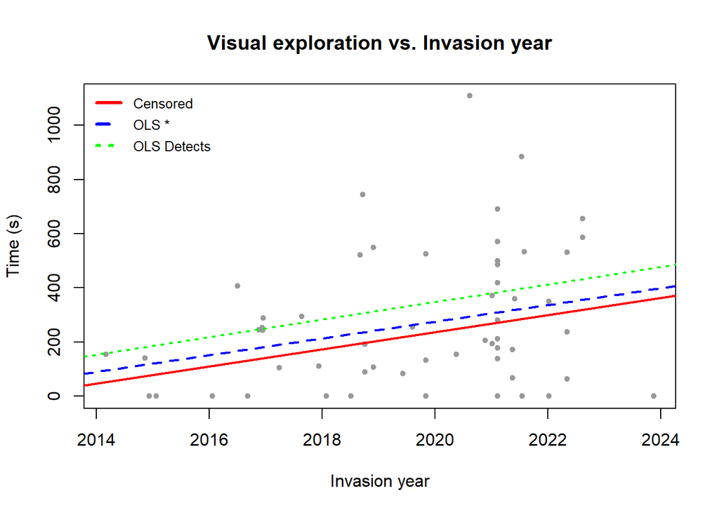

```r
# Plot the results
lineplot <- function() {

  # Add lines
  abline(coef(fit.cen)[1:2], col = "red", lwd = 2)
  abline(coef(fit.OLS), col = "blue", lty = 2, lwd = 2)
  abline(coef(fit.detect), col = "green", lty = 3, lwd = 2)

  # Add legend
  legend(
    "topleft",
    legend = c(
      "Censored",
      "OLS *",
      "OLS Detects"
    ),
    lwd = 3 * par("cex"),
    col = c("red", "blue", "green"),
    lty = c(1, 2, 3),
    text.font = 1, bty = "n",
    pt.cex = 1, cex = 0.8, y.intersp = 1.3
  )
}

plot(summary_tracking_complete_no_rep$Year_invasion, (summary_tracking_complete_no_rep$Visual_exp), pch = 19, cex = 0.7, col = 'grey60', main = "Visual exploration vs. Invasion year", xlab = "Invasion year", ylab = "Time (s)")

lineplot()
```

```r
# ~ Distance to Noah's garden
# Censored regression
fit.cen <- censReg((Visual_exp) ~ Distance_Noahs, data = summary_tracking_complete_no_rep, left = 0, right = Inf)

summary(fit.cen)
```

```
Call:
censReg(formula = (Visual_exp) ~ Distance_Noahs, left = 0, right = Inf,
    data = summary_tracking_complete_no_rep)

Observations:
         Total  Left-censored     Uncensored Right-censored
            58             13             45              0

Coefficients:
                Estimate Std. error t value Pr(> t)
(Intercept)    -53.64557  142.81219  -0.376  0.7072
Distance_Noahs   0.02933    0.01427   2.055  0.0399 *
logSigma         5.67778    0.11122  51.050  <2e-16 ***
---
Signif. codes:  0 '***' 0.001 '**' 0.01 '*' 0.05 '.' 0.1 ' ' 1

Newton-Raphson maximisation, 10 iterations
Return code 1: gradient close to zero (gradtol)
Log-likelihood: -332.2782 on 3 Df
```

```r
# Fit a line using OLS regression (linear regression)
fit.OLS <- lm((Visual_exp) ~ Distance_Noahs, data = summary_tracking_complete_no_rep)

summary(fit.OLS)
```

```
Call:
lm(formula = (Visual_exp) ~ Distance_Noahs, data = summary_tracking_complete_no_rep)

Residuals:
   Min     1Q Median     3Q    Max
-407.4 -161.0  -66.5  173.3  783.1

Coefficients:
                Estimate Std. Error t value Pr(>|t|)
(Intercept)      0.42409  114.11273   0.004    0.997
Distance_Noahs   0.02764    0.01144   2.415    0.019 *
---
Signif. codes:  0 '***' 0.001 '**' 0.01 '*' 0.05 '.' 0.1 ' ' 1

Residual standard error: 242.1 on 56 degrees of freedom
Multiple R-squared:  0.09435,   Adjusted R-squared:  0.07818
F-statistic: 5.834 on 1 and 56 DF,  p-value: 0.01901
```

```r
# fit regression only of non-censored data
fit.detect <- lm(Visual_exp ~ Distance_Noahs, data = summary_tracking_complete_no_rep_detect)

summary(fit.detect)
```

```
Call:
lm(formula = Visual_exp ~ Distance_Noahs, data = summary_tracking_complete_no_rep_detect)

Residuals:
    Min      1Q  Median      3Q     Max
-305.46 -173.18  -45.79  138.87  689.94

Coefficients:
                Estimate Std. Error t value Pr(>|t|)
(Intercept)      2.96263  115.53551   0.026  0.97966
Distance_Noahs   0.03536    0.01158   3.053  0.00387 **
---
Signif. codes:  0 '***' 0.001 '**' 0.01 '*' 0.05 '.' 0.1 ' ' 1

Residual standard error: 216.3 on 43 degrees of freedom
Multiple R-squared:  0.1782,    Adjusted R-squared:  0.1591
F-statistic: 9.324 on 1 and 43 DF,  p-value: 0.003872
```